# **Effects of Barge Movements on the Environment of New Orleans**

By Madeline Nellis and Caroline Casella

[Github Repository Link](https://github.com/madelinenellis/madelinenellis.github.io.git)

# Introduction

This project is a collaboration between Caroline Casella and Madeline Nellis for our Data Science class with Aron Culotta. We will be examining how the rates of barge movements down the Mississippi river affect the air quality, water quality, effect on wildlife, and the sinking of New Orleans.

Climate change and the changing environment are increasily worrysome and apparent, especially in New Orleans, a city that is affect by increasing amounts of hurricanes. Humans notoriously harm the environment around them, and we are seeking to find out if barges in the Mississippi are harming New Orleans.

Through our analysis we are exploring the following questions.

1. How do barge movements impact different aspects of air quality (methane, CO2, etc.)?
2. How do increased barge movements change water composition?

The impacts of the industry may alter the physical and local environment in New Orleans, and further the affects of climate change. This is important because if the barge movements are causing significant change to the environment it is important for the people of New Orleans, the people being effected, to know and be able to take neccessary legislative actions.

# Housekeeping

```python
# first, mount your google drive, change to the course folder, pull latest changes, and change to the lab folder.
from google.colab import drive
drive.mount('/content/drive')
%cd /content/drive/My Drive/Data-Science-Project
```

```
/content/drive/My Drive/Data-Science-Project
```

```python
import pandas as pd
import matplotlib.pyplot as plt
```

# Examining Barge Movements

The first step needed is to read the dataset into a dataframe. Once the data has been read, we will clean it to prepare it for analysis and add any other data that we deem important.

### Reading the Data

The barge data was collected by the United States Department of Agriculture.

Website: https://agtransport.usda.gov/Barge/Downbound-Barge-Grain-Movements-Tons-/n4pw-9ygw

```python
# Read in Barge Movement file
df = pd.read_csv("DownboundBarge.csv")
df
```

|  | Date | Week | Month | Year | Commodity | Lock | Tons |
| --- | --- | --- | --- | --- | --- | --- | --- |
| 0 | 06/27/2020 | 26 | 6 | 2020 | Corn | Ark Lock 1 | 1400.0 |
| 1 | 06/27/2020 | 26 | 6 | 2020 | Other Grain | Ark Lock 1 | 0.0 |
| 2 | 06/27/2020 | 26 | 6 | 2020 | Soybeans | Ark Lock 1 | 11200.0 |
| 3 | 06/27/2020 | 26 | 6 | 2020 | Wheat | Ark Lock 1 | 23800.0 |
| 4 | 06/27/2020 | 26 | 6 | 2020 | Corn | Miss Locks 27 | 452800.0 |
| ... | ... | ... | ... | ... | ... | ... | ... |
| 12367 | 10/01/2022 | 39 | 9 | 2022 | Wheat | Miss Locks 27 | 1600.0 |
| 12368 | 10/01/2022 | 39 | 9 | 2022 | Corn | Ohio Olmsted | 54550.0 |
| 12369 | 10/01/2022 | 39 | 9 | 2022 | Other Grain | Ohio Olmsted | 0.0 |
| 12370 | 10/01/2022 | 39 | 9 | 2022 | Soybeans | Ohio Olmsted | 45850.0 |
| 12371 | 10/01/2022 | 39 | 9 | 2022 | Wheat | Ohio Olmsted | 1750.0 |

12372 rows × 7 columns

This data set ranges from 2003 to 2022. The date object in this frame needs to be converted to a datetime object so that we can compare with other data sets.

```python
# convert date to datetime object
from datetime import datetime
df['Date'] = pd.to_datetime(df['Date'], errors='coerce')
#df["date"] = df["Date"].dt.date
```

Checking the dtypes of the dataframe to ensure they are formatted correctly:

```python
df.dtypes
```

```
Date         datetime64[ns]
Week                  int64
Month                 int64
Year                  int64
Commodity            object
Lock                 object
Tons                float64
dtype: object
```

```python
# Generate table with mean number of tons moved per week in the year over all the years in the data set
tonsPerWeek = df.groupby('Week', as_index=True).agg({'Tons': 'mean'})
tonsPerWeek.head()
```

| Week | Tons |
| --- | --- |
| 1 | 43772.872340 |
| 2 | 50313.557447 |
| 3 | 53843.773109 |
| 4 | 53187.381356 |
| 5 | 50246.974895 |

This graph displays the tons per week.

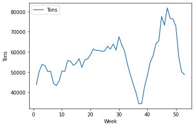

```python
tonsPerWeek.plot()
plt.ylabel('Tons')
```

Now we are going to look at the different commodities, and what is moved the most.

```python
#Generate table with total number of tons per commodity
mostMovedCommodity = df.groupby('Commodity', as_index=True).agg({'Tons': 'sum'})
mostMovedCommodity
```

| Commodity | Tons |
| --- | --- |
| Corn | 420725635.0 |
| Other Grain | 8220839.0 |
| Soybeans | 223048957.0 |
| Wheat | 38194050.0 |

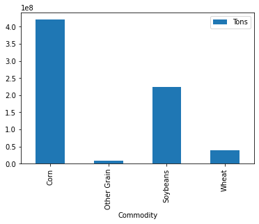

```python
mostMovedCommodity.pivot_table(
    index="Commodity",
    values="Tons").plot.bar()
```

```python
#Tons of Each Commodity Per Week
mostMovedCommodityPerWeek = df.groupby(["Week", "Commodity"])["Tons"].mean()
mostMovedCommodityPerWeek
```

```
Week  Commodity
1     Corn            88800.203390
      Other Grain      3372.568966
      Soybeans        74889.372881
      Wheat            7344.593220
2     Corn           105349.396552
                         ...
52    Wheat            6459.107143
53    Corn           106683.083333
      Other Grain      1200.000000
      Soybeans        81566.750000
      Wheat            5596.166667
Name: Tons, Length: 212, dtype: float64
```

The following data frame and graph show the number of moved tons per day over the entire data set, so from 2003 to 2022. This can show us changes in barge movements over a long period of time.

```python
#Tons moved per day
tonsPerDay = df.groupby(['Date']).agg({'Tons': 'sum'})
tonsPerDay
```

| Date | Tons |
| --- | --- |
| 2003-01-04 | 619632.0 |
| 2003-01-11 | 817443.0 |
| 2003-01-18 | 1034636.0 |
| 2003-01-25 | 885924.0 |
| 2003-02-01 | 628789.0 |
| ... | ... |
| 2022-09-03 | 240500.0 |
| 2022-09-10 | 249727.0 |
| 2022-09-17 | 209600.0 |
| 2022-09-24 | 220300.0 |
| 2022-10-01 | 316850.0 |

1031 rows × 1 columns

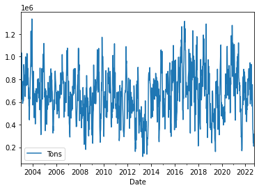

```python
tonsPerDay.plot.line()
```

We also want to see if there are seasonal changes in the barge movements, so we grouped the data by day and month of the year and took averages over all the years.

```python
tonsPerDayMean = tonsPerDay.reset_index()
tonsPerDayMean['dayMonth'] = tonsPerDayMean['Date'].dt.strftime("%m-%d")
tonsPerDayMean = tonsPerDayMean.groupby(['dayMonth']).agg({'Tons': 'mean'})
```

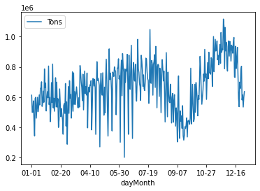

```python
tonsPerDayMean.plot.line()
```

The barge movements steadily increase from January to August then decrease all of August and start to increase again from September until December and the decrease until the new year. Initial thoughts are that this could be attributed to weather and temperature changes in New Orleans.

# Examining Air Quality

The air quality data is collected from the Louisiana Department of Environmental Quality.

Website: https://airquality.deq.louisiana.gov/

This data has limitations. Our barge movement data goes back until 2003, but the air quality data is only one years worth of data from June 27th 2020 until June 21st 2021. Although we would like to look at barge movements relationships with air quality over a longer period of time, we can still look at the relationship within a year.

```python
air = pd.read_csv("AirQualityHourIntervals.csv")
air
```

|  | Date | H2S-PPB | ITEMP-DEGC | METHANE-PPM | NMOC-PPM | PM25-UG/M3 | SO2-PPB | THC-PPM | WDIR-DEG | WSP-MPH |
| --- | --- | --- | --- | --- | --- | --- | --- | --- | --- | --- |
| 0 | Jun 27 2020 12:00AM | 1.0 | 24.3 | 2.11 | 0.00 | 16.7 | 0.0 | 2.10 | 142.0 | 2.0 |
| 1 | Jun 27 2020 1:00AM | 2.0 | 24.1 | 2.23 | 0.00 | 17.1 | 0.0 | 2.21 | 134.0 | 3.0 |
| 2 | Jun 27 2020 2:00AM | 1.0 | 24.1 | 2.30 | 0.00 | 17.3 | 0.0 | 2.27 | 138.0 | 5.0 |
| 3 | Jun 27 2020 3:00AM | 1.0 | 24.2 | 2.31 | 0.00 | 15.6 | 0.0 | 2.28 | 139.0 | 4.0 |
| 4 | Jun 27 2020 4:00AM | 2.0 | 24.3 | 2.33 | 0.00 | 16.0 | 0.0 | 2.30 | 157.0 | 3.0 |
| ... | ... | ... | ... | ... | ... | ... | ... | ... | ... | ... |
| 8573 | Jun 21 2021 7:00AM | 2.0 | 27.3 | 2.15 | 0.01 | 8.0 | 0.2 | 2.12 | 153.0 | 3.0 |
| 8574 | Jun 21 2021 8:00AM | 2.0 | 27.1 | 2.16 | 0.01 | 11.4 | 0.2 | 2.14 | 200.0 | 1.0 |
| 8575 | Jun 21 2021 9:00AM | 2.0 | 27.0 | 3.98 | 0.01 | 8.5 | 0.3 | 3.95 | 230.0 | 3.0 |
| 8576 | Jun 21 2021 10:00AM | 2.0 | 27.0 | 2.16 | 0.01 | 11.1 | 0.3 | 2.14 | 182.0 | 5.0 |
| 8577 | Jun 21 2021 11:00AM | 1.0 | 26.2 | 1.96 | 0.01 | 9.9 | 0.1 | 1.93 | 189.0 | 9.0 |

8578 rows × 10 columns

```python
air = air.rename(columns={'METHANE-PPM': 'Methane'})
```

Below we converted Date to datetime object to make it comparable with other data sets. And separated the time out into a separate column because the barge movement datetime object does not include time.

```python
#convert Date to datetime object
from datetime import datetime
air['Date'] = pd.to_datetime(air["Date"], errors='coerce')
```

```python
#separate date and time for mean by day calculations
air["date"] = air["Date"].dt.date
air["time"] = air["Date"].dt.time
```

Here we displayed the dtypes to ensure they are all correct.

```python
air.dtypes
```

```
Date          datetime64[ns]
H2S-PPB              float64
ITEMP-DEGC           float64
Methane              float64
NMOC-PPM             float64
PM25-UG/M3           float64
SO2-PPB              float64
THC-PPM              float64
WDIR-DEG             float64
WSP-MPH              float64
date                  object
time                  object
dtype: object
```

Now we start some exploratory analysis to better understand the air quality data.

### Methane

Here we separated out just the methane data in order to do a deeper analysis of its effect. Methane is a hydrocarbon that is a primary component of natural gas. Methane is also a greenhouse gas (GHG), so its presence in the atmosphere affects the earth's temperature and climate system. Methane is produced naturally (cows), but emission may also human caused by landfills, oil and natural gas systems, agricultural activities, coal mining, stationary and mobile combustion, wastewater treatment, and certain industrial processes

```python
#calculate the mean Methane per day
meanMethanePerDay = air.groupby('date', as_index=True).agg({'Methane': 'mean'})
meanMethanePerDay
```

| date | Methane |
| --- | --- |
| 2020-06-27 | 2.120000 |
| 2020-06-28 | 2.984167 |
| 2020-06-29 | 2.861250 |
| 2020-06-30 | 4.554167 |
| 2020-07-01 | 5.987500 |
| ... | ... |
| 2021-06-17 | 2.047917 |
| 2021-06-18 | 1.932500 |
| 2021-06-19 | 2.711250 |
| 2021-06-20 | 3.147500 |
| 2021-06-21 | 2.679167 |

359 rows × 1 columns

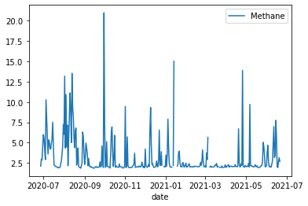

```python
meanMethanePerDay.plot.line()
```

### Sulfur Dioxide

Next, we separated out the sulfure dioxide to analyze its effect. SO2 is used as the indicator for the larger group of gaseous sulfur oxides (SOx) because other gases of this group are usually found at much lower concentrations. Sulfur dioxide is mainly produced by fossil fuel combustion at power plants andother industrial facilities.

```python
air = air.rename(columns={'SO2-PPB': 'SulfurDioxide'})
```

```python
meanSDPerDay= air.groupby('date', as_index=True).agg({'SulfurDioxide': 'mean'})
meanSDPerDay
```

| date | SulfurDioxide |
| --- | --- |
| 2020-06-27 | 0.004167 |
| 2020-06-28 | 0.000000 |
| 2020-06-29 | 0.008333 |
| 2020-06-30 | 0.008696 |
| 2020-07-01 | 0.016667 |
| ... | ... |
| 2021-06-17 | 0.445833 |
| 2021-06-18 | 0.308696 |
| 2021-06-19 | 0.370833 |
| 2021-06-20 | 0.254167 |
| 2021-06-21 | 0.250000 |

359 rows × 1 columns

### Hydrogen Sulfide

Hydrogen sulfide also occurs naturally in sewers, manure pits, well water, oil and gas wells, and volcanoes. Because it is heavier than air, hydrogen sulfide can collect in low-lying and enclosed spaces. It has immediate impacts on people if they come in contact with it, which can range from irritation to unconsciousness and death

```python
air = air.rename(columns={'H2S-PPB': 'HydrogenSulfide'})
```

```python
meanHSPerDay= air.groupby('date', as_index=True).agg({'HydrogenSulfide': 'mean'})
meanHSPerDay
```

| date | HydrogenSulfide |
| --- | --- |
| 2020-06-27 | 1.541667 |
| 2020-06-28 | 2.347826 |
| 2020-06-29 | 2.304348 |
| 2020-06-30 | 2.208333 |
| 2020-07-01 | 2.217391 |
| ... | ... |
| 2021-06-17 | 1.541667 |
| 2021-06-18 | 1.541667 |
| 2021-06-19 | 1.791667 |
| 2021-06-20 | 2.000000 |
| 2021-06-21 | 2.500000 |

359 rows × 1 columns

### Particulate Matter

Particulate Matter (PM) is a mixture of solid and liquid particles that are suspended in the air. These are categorized into coarse, fine and ultrafine. It is used when describing pollutant levels where health impact from exposure considers amount of PM2.5 over a 24-hour period.

```python
air = air.rename(columns={'PM25-UG/M3': 'PM'})
```

```python
air
```

|  | Date | HydrogenSulfide | ITEMP-DEGC | Methane | NMOC-PPM | PM | SulfurDioxide | THC-PPM | WDIR-DEG | WSP-MPH | date | time |
| --- | --- | --- | --- | --- | --- | --- | --- | --- | --- | --- | --- | --- |
| 0 | 2020-06-27 00:00:00 | 1.0 | 24.3 | 2.11 | 0.00 | 16.7 | 0.0 | 2.10 | 142.0 | 2.0 | 2020-06-27 | 00:00:00 |
| 1 | 2020-06-27 01:00:00 | 2.0 | 24.1 | 2.23 | 0.00 | 17.1 | 0.0 | 2.21 | 134.0 | 3.0 | 2020-06-27 | 01:00:00 |
| 2 | 2020-06-27 02:00:00 | 1.0 | 24.1 | 2.30 | 0.00 | 17.3 | 0.0 | 2.27 | 138.0 | 5.0 | 2020-06-27 | 02:00:00 |
| 3 | 2020-06-27 03:00:00 | 1.0 | 24.2 | 2.31 | 0.00 | 15.6 | 0.0 | 2.28 | 139.0 | 4.0 | 2020-06-27 | 03:00:00 |
| 4 | 2020-06-27 04:00:00 | 2.0 | 24.3 | 2.33 | 0.00 | 16.0 | 0.0 | 2.30 | 157.0 | 3.0 | 2020-06-27 | 04:00:00 |
| ... | ... | ... | ... | ... | ... | ... | ... | ... | ... | ... | ... | ... |
| 8573 | 2021-06-21 07:00:00 | 2.0 | 27.3 | 2.15 | 0.01 | 8.0 | 0.2 | 2.12 | 153.0 | 3.0 | 2021-06-21 | 07:00:00 |
| 8574 | 2021-06-21 08:00:00 | 2.0 | 27.1 | 2.16 | 0.01 | 11.4 | 0.2 | 2.14 | 200.0 | 1.0 | 2021-06-21 | 08:00:00 |
| 8575 | 2021-06-21 09:00:00 | 2.0 | 27.0 | 3.98 | 0.01 | 8.5 | 0.3 | 3.95 | 230.0 | 3.0 | 2021-06-21 | 09:00:00 |
| 8576 | 2021-06-21 10:00:00 | 2.0 | 27.0 | 2.16 | 0.01 | 11.1 | 0.3 | 2.14 | 182.0 | 5.0 | 2021-06-21 | 10:00:00 |
| 8577 | 2021-06-21 11:00:00 | 1.0 | 26.2 | 1.96 | 0.01 | 9.9 | 0.1 | 1.93 | 189.0 | 9.0 | 2021-06-21 | 11:00:00 |

8578 rows × 12 columns

```python
meanPMPerDay= air.groupby('date', as_index=True).agg({'PM': 'mean'})
meanPMPerDay
```

| date | PM |
| --- | --- |
| 2020-06-27 | 14.950000 |
| 2020-06-28 | 11.258333 |
| 2020-06-29 | 21.104348 |
| 2020-06-30 | 20.866667 |
| 2020-07-01 | 25.700000 |
| ... | ... |
| 2021-06-17 | 15.865217 |
| 2021-06-18 | 9.352174 |
| 2021-06-19 | 4.791667 |
| 2021-06-20 | 6.900000 |
| 2021-06-21 | 7.808333 |

359 rows × 1 columns

# Examining Water Quality

Data was collected from the United States Geological Survey at site number 7374000 on the Mississippi River.

```python
water_qual = pd.read_csv('water_quality.tsv', sep='\t', lineterminator='\r')
water_qual
```

|  | agency_cd | site_no | datetime | Turbidity, formazin nephelometric units (FNU) (Mean) | Unnamed: 4 | Turbidity, formazin nephelometric units (FNU) (Max) | Unnamed: 6 | Turbidity, formazin nephelometric units (FNU) (Min) | Unnamed: 8 | Gage height, feet (Mean) | ... | pH, water, unfiltered, field, standard units (Minimum) | Unnamed: 36 | pH, water, unfiltered, field, standard units (Median) | Unnamed: 38 | Discharge, cubic feet per second (Mean) | Unnamed: 40 | Dissolved oxygen, water, unfiltered, milligrams per liter (Mean) | Unnamed: 42 | Nitrate plus nitrite, water, in situ, milligrams per liter as nitrogen (Mean) | Unnamed: 44 |
| --- | --- | --- | --- | --- | --- | --- | --- | --- | --- | --- | --- | --- | --- | --- | --- | --- | --- | --- | --- | --- | --- |
| 0 | \n5s | 15s | 20d | 14n | 10s | 14n | 10s | 14n | 10s | 14n | ... | 14n | 10s | 14n | 10s | 14n | 10s | 14n | 10s | 14n | 10s |
| 1 | \nUSGS | 7374000 | 2021-12-07 | 48.1 | P | 66.4 | P | 39.6 | P | 10.21 | ... | 7.9 | P | 8 | P | 286000 | P | 10.2 | P | 1.3 | P |
| 2 | \nUSGS | 7374000 | 2021-12-08 | 28.9 | P | 47.3 | P | 22.3 | P | 9.67 | ... | 8 | P | 8 | P | 276000 | P | 10.3 | P | 1.31 | P |
| 3 | \nUSGS | 7374000 | 2021-12-09 | 25.1 | P | 33.2 | P | 18.4 | P | 9.12 | ... | 8 | P | 8 | P | 264000 | P | 10.3 | P | 1.31 | P |
| 4 | \nUSGS | 7374000 | 2021-12-10 | 24.8 | P | 34.3 | P | 19.1 | P | 8.58 | ... | 8 | P | 8 | P | 253000 | P | 10.2 | P | 1.27 | P |
| ... | ... | ... | ... | ... | ... | ... | ... | ... | ... | ... | ... | ... | ... | ... | ... | ... | ... | ... | ... | ... | ... |
| 362 | \nUSGS | 7374000 | 2022-12-03 | 21.2 | P | 23.5 | P | 19 | P | 8.66 | ... | 8.1 | P | 8.1 | P | 242000 | P | 10.5 | P | 0.8 | P |
| 363 | \nUSGS | 7374000 | 2022-12-04 | 20.7 | P | 22.6 | P | 16.1 | P | 8.4 | ... | 8.1 | P | 8.1 | P | 233000 | P | 10.5 | P | 0.78 | P |
| 364 | \nUSGS | 7374000 | 2022-12-05 | 23.1 | P | 33.3 | P | 18.1 | P | 7.97 | ... | 8.1 | P | 8.1 | P | 224000 | P | 10.4 | P | 0.77 | P |
| 365 | \nUSGS | 7374000 | 2022-12-06 | 30.9 | P | 39.3 | P | 24.9 | P | 7.89 | ... | 8.1 | P | 8.1 | P | 219000 | P | 10.3 | P | 0.81 | P |
| 366 | \nUSGS | 7374000 | 2022-12-07 | 31.8 | P | 36.6 | P | 27.9 | P | 7.59 | ... | 8.1 | P | 8.1 | P | 213000 | P | 10.3 | P | 0.82 | P |

367 rows × 45 columns

```python
#remove all the unneeded columns
del water_qual['Unnamed: 4']
del water_qual['Unnamed: 6']
del water_qual['Unnamed: 8']
del water_qual['Unnamed: 10']
del water_qual['Unnamed: 12']
del water_qual['Unnamed: 14']
del water_qual['Unnamed: 16']
del water_qual['Unnamed: 18']
del water_qual['Unnamed: 20']
del water_qual['Unnamed: 22']
del water_qual['Unnamed: 24']
del water_qual['Unnamed: 26']
del water_qual['Unnamed: 28']
del water_qual['Unnamed: 30']
del water_qual['Unnamed: 32']
del water_qual['Unnamed: 34']
del water_qual['Unnamed: 36']
del water_qual['Unnamed: 38']
del water_qual['Unnamed: 40']
del water_qual['Unnamed: 42']
del water_qual['Unnamed: 44']
del water_qual['agency_cd']
del water_qual['site_no']
water_qual = water_qual.drop(labels=0, axis=0)
```

```python
water_qual
```

|  | datetime | Turbidity, formazin nephelometric units (FNU) (Mean) | Turbidity, formazin nephelometric units (FNU) (Max) | Turbidity, formazin nephelometric units (FNU) (Min) | Gage height, feet (Mean) | Gage height, feet (Minimum) | Gage height, feet (Mean).1 | Temperature, water, degrees Celsius (Maximum) | Temperature, water, degrees Celsius (Minimum) | Temperature, water, degrees Celsius (Mean) | ... | Specific conductance, water, unfiltered, microsiemens per centimeter at 25 degrees Celsius (Mean) | Salinity, water, unfiltered, parts per thousand (Maximum) | Salinity, water, unfiltered, parts per thousand (Minimum) | Salinity, water, unfiltered, parts per thousand (Mean) | pH, water, unfiltered, field, standard units (Maximum) | pH, water, unfiltered, field, standard units (Minimum) | pH, water, unfiltered, field, standard units (Median) | Discharge, cubic feet per second (Mean) | Dissolved oxygen, water, unfiltered, milligrams per liter (Mean) | Nitrate plus nitrite, water, in situ, milligrams per liter as nitrogen (Mean) |
| --- | --- | --- | --- | --- | --- | --- | --- | --- | --- | --- | --- | --- | --- | --- | --- | --- | --- | --- | --- | --- | --- |
| 1 | 2021-12-07 | 48.1 | 66.4 | 39.6 | 10.21 | 9.55 | 9.95 | 12.1 | 11.8 | 11.9 | ... | 442 | 0.2 | 0.2 | 0.2 | 8 | 7.9 | 8 | 286000 | 10.2 | 1.3 |
| 2 | 2021-12-08 | 28.9 | 47.3 | 22.3 | 9.67 | 9.07 | 9.48 | 11.9 | 11.6 | 11.8 | ... | 462 | 0.2 | 0.2 | 0.2 | 8 | 8 | 8 | 276000 | 10.3 | 1.31 |
| 3 | 2021-12-09 | 25.1 | 33.2 | 18.4 | 9.12 | 8.55 | 8.95 | 11.9 | 11.6 | 11.8 | ... | 461 | 0.2 | 0.2 | 0.2 | 8 | 8 | 8 | 264000 | 10.3 | 1.31 |
| 4 | 2021-12-10 | 24.8 | 34.3 | 19.1 | 8.58 | 8.32 | 8.49 | 12.3 | 11.9 | 12.1 | ... | 469 | 0.2 | 0.2 | 0.2 | 8 | 8 | 8 | 253000 | 10.2 | 1.27 |
| 5 | 2021-12-11 | 22.1 | 32.8 | 15.5 | 8.38 | 8.14 | 8.27 | 12.6 | 12.2 | 12.4 | ... | 474 | 0.3 | 0.2 | 0.2 | 8 | 8 | 8 | 248000 | 10.2 | 1.25 |
| ... | ... | ... | ... | ... | ... | ... | ... | ... | ... | ... | ... | ... | ... | ... | ... | ... | ... | ... | ... | ... | ... |
| 362 | 2022-12-03 | 21.2 | 23.5 | 19 | 8.66 | 8.35 | 8.49 | 11.9 | 11.7 | 11.8 | ... | 479 | 0.2 | 0.2 | 0.2 | 8.2 | 8.1 | 8.1 | 242000 | 10.5 | 0.8 |
| 363 | 2022-12-04 | 20.7 | 22.6 | 16.1 | 8.4 | 7.88 | 8.15 | 11.9 | 11.7 | 11.8 | ... | 461 | 0.2 | 0.2 | 0.2 | 8.1 | 8.1 | 8.1 | 233000 | 10.5 | 0.78 |
| 364 | 2022-12-05 | 23.1 | 33.3 | 18.1 | 7.97 | 7.59 | 7.79 | 12.1 | 11.8 | 11.9 | ... | 472 | 0.2 | 0.2 | 0.2 | 8.1 | 8.1 | 8.1 | 224000 | 10.4 | 0.77 |
| 365 | 2022-12-06 | 30.9 | 39.3 | 24.9 | 7.89 | 7.25 | 7.59 | 12.2 | 11.8 | 12 | ... | 471 | 0.2 | 0.2 | 0.2 | 8.1 | 8.1 | 8.1 | 219000 | 10.3 | 0.81 |
| 366 | 2022-12-07 | 31.8 | 36.6 | 27.9 | 7.59 | 7.08 | 7.36 | 12.3 | 11.9 | 12.1 | ... | 458 | 0.2 | 0.2 | 0.2 | 8.1 | 8.1 | 8.1 | 213000 | 10.3 | 0.82 |

366 rows × 22 columns

```python
from datetime import datetime
water_qual['datetime'] = pd.to_datetime(water_qual['datetime'], errors='coerce')
```

```python
water_qual.dtypes
```

```
datetime                                                                                                datetime64[ns]
Turbidity, formazin nephelometric units (FNU) (Mean)                                                            object
Turbidity, formazin nephelometric units (FNU) (Max)                                                             object
Turbidity, formazin nephelometric units (FNU) (Min)                                                             object
Gage height, feet (Mean)                                                                                        object
 Gage height, feet (Minimum)                                                                                    object
Gage height, feet (Mean).1                                                                                      object
Temperature, water, degrees Celsius (Maximum)                                                                   object
Temperature, water, degrees Celsius (Minimum)                                                                   object
Temperature, water, degrees Celsius (Mean)                                                                      object
Specific conductance, water, unfiltered, microsiemens per centimeter at 25 degrees Celsius (Maximum)            object
Specific conductance, water, unfiltered, microsiemens per centimeter at 25 degrees Celsius (Minimum)            object
Specific conductance, water, unfiltered, microsiemens per centimeter at 25 degrees Celsius (Mean)               object
Salinity, water, unfiltered, parts per thousand (Maximum)                                                       object
Salinity, water, unfiltered, parts per thousand (Minimum)                                                       object
Salinity, water, unfiltered, parts per thousand (Mean)                                                          object
pH, water, unfiltered, field, standard units (Maximum)                                                          object
pH, water, unfiltered, field, standard units (Minimum)                                                          object
pH, water, unfiltered, field, standard units (Median)                                                           object
Discharge, cubic feet per second (Mean)                                                                         object
Dissolved oxygen, water, unfiltered, milligrams per liter (Mean)                                                object
Nitrate plus nitrite, water, in situ, milligrams per liter as nitrogen (Mean)                                   object
dtype: object
```

### Turbidity

Turbidity is the measure of relative clarity of a liquid. It is an optical characteristic of water and is a measurement of the amount of light that is scattered by material in the water when a light is shined through the water sample. The higher the intensity of scattered light, the higher the turbidity. Material that causes water to be turbid include clay, silt, very tiny inorganic and organic matter, algae, dissolved colored organic compounds, and plankton and other microscopic organisms.

```python
#sorting the water quality
water_qual = water_qual.rename(columns={'Turbidity, formazin nephelometric units (FNU) (Mean)': 'Turbidity Mean'})
water_qual = water_qual.rename(columns={'Turbidity, formazin nephelometric units (FNU) (Max)':'Turbidity Max'})
water_qual = water_qual.rename(columns={'Turbidity, formazin nephelometric units (FNU) (Min)': 'Turbidity Min'})
water_qual = water_qual.rename(columns={'datetime':'Date'})
water_qual
```

|  | Date | Turbidity Mean | Turbidity Max | Turbidity Min | Gage height, feet (Mean) | Gage height, feet (Minimum) | Gage height, feet (Mean).1 | Temperature, water, degrees Celsius (Maximum) | Temperature, water, degrees Celsius (Minimum) | Temperature, water, degrees Celsius (Mean) | ... | Specific conductance, water, unfiltered, microsiemens per centimeter at 25 degrees Celsius (Mean) | Salinity, water, unfiltered, parts per thousand (Maximum) | Salinity, water, unfiltered, parts per thousand (Minimum) | Salinity, water, unfiltered, parts per thousand (Mean) | pH, water, unfiltered, field, standard units (Maximum) | pH, water, unfiltered, field, standard units (Minimum) | pH, water, unfiltered, field, standard units (Median) | Discharge, cubic feet per second (Mean) | Dissolved oxygen, water, unfiltered, milligrams per liter (Mean) | Nitrate plus nitrite, water, in situ, milligrams per liter as nitrogen (Mean) |
| --- | --- | --- | --- | --- | --- | --- | --- | --- | --- | --- | --- | --- | --- | --- | --- | --- | --- | --- | --- | --- | --- |
| 1 | 2021-12-07 | 48.1 | 66.4 | 39.6 | 10.21 | 9.55 | 9.95 | 12.1 | 11.8 | 11.9 | ... | 442 | 0.2 | 0.2 | 0.2 | 8 | 7.9 | 8 | 286000 | 10.2 | 1.3 |
| 2 | 2021-12-08 | 28.9 | 47.3 | 22.3 | 9.67 | 9.07 | 9.48 | 11.9 | 11.6 | 11.8 | ... | 462 | 0.2 | 0.2 | 0.2 | 8 | 8 | 8 | 276000 | 10.3 | 1.31 |
| 3 | 2021-12-09 | 25.1 | 33.2 | 18.4 | 9.12 | 8.55 | 8.95 | 11.9 | 11.6 | 11.8 | ... | 461 | 0.2 | 0.2 | 0.2 | 8 | 8 | 8 | 264000 | 10.3 | 1.31 |
| 4 | 2021-12-10 | 24.8 | 34.3 | 19.1 | 8.58 | 8.32 | 8.49 | 12.3 | 11.9 | 12.1 | ... | 469 | 0.2 | 0.2 | 0.2 | 8 | 8 | 8 | 253000 | 10.2 | 1.27 |
| 5 | 2021-12-11 | 22.1 | 32.8 | 15.5 | 8.38 | 8.14 | 8.27 | 12.6 | 12.2 | 12.4 | ... | 474 | 0.3 | 0.2 | 0.2 | 8 | 8 | 8 | 248000 | 10.2 | 1.25 |
| ... | ... | ... | ... | ... | ... | ... | ... | ... | ... | ... | ... | ... | ... | ... | ... | ... | ... | ... | ... | ... | ... |
| 362 | 2022-12-03 | 21.2 | 23.5 | 19 | 8.66 | 8.35 | 8.49 | 11.9 | 11.7 | 11.8 | ... | 479 | 0.2 | 0.2 | 0.2 | 8.2 | 8.1 | 8.1 | 242000 | 10.5 | 0.8 |
| 363 | 2022-12-04 | 20.7 | 22.6 | 16.1 | 8.4 | 7.88 | 8.15 | 11.9 | 11.7 | 11.8 | ... | 461 | 0.2 | 0.2 | 0.2 | 8.1 | 8.1 | 8.1 | 233000 | 10.5 | 0.78 |
| 364 | 2022-12-05 | 23.1 | 33.3 | 18.1 | 7.97 | 7.59 | 7.79 | 12.1 | 11.8 | 11.9 | ... | 472 | 0.2 | 0.2 | 0.2 | 8.1 | 8.1 | 8.1 | 224000 | 10.4 | 0.77 |
| 365 | 2022-12-06 | 30.9 | 39.3 | 24.9 | 7.89 | 7.25 | 7.59 | 12.2 | 11.8 | 12 | ... | 471 | 0.2 | 0.2 | 0.2 | 8.1 | 8.1 | 8.1 | 219000 | 10.3 | 0.81 |
| 366 | 2022-12-07 | 31.8 | 36.6 | 27.9 | 7.59 | 7.08 | 7.36 | 12.3 | 11.9 | 12.1 | ... | 458 | 0.2 | 0.2 | 0.2 | 8.1 | 8.1 | 8.1 | 213000 | 10.3 | 0.82 |

366 rows × 22 columns

```python
turbidity = water_qual.filter(['Date', 'Turbidity Mean'], axis = 1)
turbidity
```

|  | Date | Turbidity Mean |
| --- | --- | --- |
| 1 | 2021-12-07 | 48.1 |
| 2 | 2021-12-08 | 28.9 |
| 3 | 2021-12-09 | 25.1 |
| 4 | 2021-12-10 | 24.8 |
| 5 | 2021-12-11 | 22.1 |
| ... | ... | ... |
| 362 | 2022-12-03 | 21.2 |
| 363 | 2022-12-04 | 20.7 |
| 364 | 2022-12-05 | 23.1 |
| 365 | 2022-12-06 | 30.9 |
| 366 | 2022-12-07 | 31.8 |

366 rows × 2 columns

```python
#convert the values from object to integers to graph
turbidity['Turbidity Mean']=turbidity['Turbidity Mean'].astype(float)
```

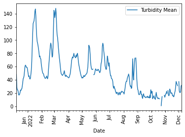

```python
turbidity.plot.line(x='Date')
plt.xticks(rotation=90)
```

### Gage Height

Gage height is the distance (or height) of the water surface above the streamgage datum reference point. Gage datum is a unique reference point to each gage site and is generally located underneath the streambed to accommodate for stream channel changes.

```python
#sorting the water quality
water_qual = water_qual.rename(columns={'Gage height, feet (Mean)': 'Gage Height Max'})
water_qual = water_qual.rename(columns={'Gage height, feet (Minimum)': 'Gage Height Min'})
water_qual = water_qual.rename(columns={'Gage height, feet (Mean).1': 'Gage Height Mean'})
water_qual
```

|  | Date | Turbidity Mean | Turbidity Max | Turbidity Min | Gage Height Max | Gage height, feet (Minimum) | Gage Height Mean | Temperature, water, degrees Celsius (Maximum) | Temperature, water, degrees Celsius (Minimum) | Temperature, water, degrees Celsius (Mean) | ... | Specific conductance, water, unfiltered, microsiemens per centimeter at 25 degrees Celsius (Mean) | Salinity, water, unfiltered, parts per thousand (Maximum) | Salinity, water, unfiltered, parts per thousand (Minimum) | Salinity, water, unfiltered, parts per thousand (Mean) | pH, water, unfiltered, field, standard units (Maximum) | pH, water, unfiltered, field, standard units (Minimum) | pH, water, unfiltered, field, standard units (Median) | Discharge, cubic feet per second (Mean) | Dissolved oxygen, water, unfiltered, milligrams per liter (Mean) | Nitrate plus nitrite, water, in situ, milligrams per liter as nitrogen (Mean) |
| --- | --- | --- | --- | --- | --- | --- | --- | --- | --- | --- | --- | --- | --- | --- | --- | --- | --- | --- | --- | --- | --- |
| 1 | 2021-12-07 | 48.1 | 66.4 | 39.6 | 10.21 | 9.55 | 9.95 | 12.1 | 11.8 | 11.9 | ... | 442 | 0.2 | 0.2 | 0.2 | 8 | 7.9 | 8 | 286000 | 10.2 | 1.3 |
| 2 | 2021-12-08 | 28.9 | 47.3 | 22.3 | 9.67 | 9.07 | 9.48 | 11.9 | 11.6 | 11.8 | ... | 462 | 0.2 | 0.2 | 0.2 | 8 | 8 | 8 | 276000 | 10.3 | 1.31 |
| 3 | 2021-12-09 | 25.1 | 33.2 | 18.4 | 9.12 | 8.55 | 8.95 | 11.9 | 11.6 | 11.8 | ... | 461 | 0.2 | 0.2 | 0.2 | 8 | 8 | 8 | 264000 | 10.3 | 1.31 |
| 4 | 2021-12-10 | 24.8 | 34.3 | 19.1 | 8.58 | 8.32 | 8.49 | 12.3 | 11.9 | 12.1 | ... | 469 | 0.2 | 0.2 | 0.2 | 8 | 8 | 8 | 253000 | 10.2 | 1.27 |
| 5 | 2021-12-11 | 22.1 | 32.8 | 15.5 | 8.38 | 8.14 | 8.27 | 12.6 | 12.2 | 12.4 | ... | 474 | 0.3 | 0.2 | 0.2 | 8 | 8 | 8 | 248000 | 10.2 | 1.25 |
| ... | ... | ... | ... | ... | ... | ... | ... | ... | ... | ... | ... | ... | ... | ... | ... | ... | ... | ... | ... | ... | ... |
| 362 | 2022-12-03 | 21.2 | 23.5 | 19 | 8.66 | 8.35 | 8.49 | 11.9 | 11.7 | 11.8 | ... | 479 | 0.2 | 0.2 | 0.2 | 8.2 | 8.1 | 8.1 | 242000 | 10.5 | 0.8 |
| 363 | 2022-12-04 | 20.7 | 22.6 | 16.1 | 8.4 | 7.88 | 8.15 | 11.9 | 11.7 | 11.8 | ... | 461 | 0.2 | 0.2 | 0.2 | 8.1 | 8.1 | 8.1 | 233000 | 10.5 | 0.78 |
| 364 | 2022-12-05 | 23.1 | 33.3 | 18.1 | 7.97 | 7.59 | 7.79 | 12.1 | 11.8 | 11.9 | ... | 472 | 0.2 | 0.2 | 0.2 | 8.1 | 8.1 | 8.1 | 224000 | 10.4 | 0.77 |
| 365 | 2022-12-06 | 30.9 | 39.3 | 24.9 | 7.89 | 7.25 | 7.59 | 12.2 | 11.8 | 12 | ... | 471 | 0.2 | 0.2 | 0.2 | 8.1 | 8.1 | 8.1 | 219000 | 10.3 | 0.81 |
| 366 | 2022-12-07 | 31.8 | 36.6 | 27.9 | 7.59 | 7.08 | 7.36 | 12.3 | 11.9 | 12.1 | ... | 458 | 0.2 | 0.2 | 0.2 | 8.1 | 8.1 | 8.1 | 213000 | 10.3 | 0.82 |

366 rows × 22 columns

```python
gageHeight = water_qual.filter(['Date','Gage Height Mean'], axis=1)
gageHeight
```

|  | Date | Gage Height Mean |
| --- | --- | --- |
| 1 | 2021-12-07 | 9.95 |
| 2 | 2021-12-08 | 9.48 |
| 3 | 2021-12-09 | 8.95 |
| 4 | 2021-12-10 | 8.49 |
| 5 | 2021-12-11 | 8.27 |
| ... | ... | ... |
| 362 | 2022-12-03 | 8.49 |
| 363 | 2022-12-04 | 8.15 |
| 364 | 2022-12-05 | 7.79 |
| 365 | 2022-12-06 | 7.59 |
| 366 | 2022-12-07 | 7.36 |

366 rows × 2 columns

```python
#
gageHeight['Gage Height Mean']=gageHeight['Gage Height Mean'].astype(float)
```

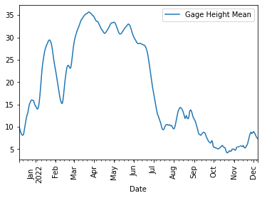

```python
gageHeight.plot.line(x='Date')
plt.xticks(rotation=90)
```

### Temperature

Temperature exerts a major influence on biological activity and growth since it governs the kinds of organisms that can live in rivers and lakes. Fish, insects, zooplankton, phytoplankton, and other aquatic species all have a preferred temperature range and as temperatures get too far above or below this preferred range, the number of individuals of the species decreases until finally there are none.

```python
#sorting the water quality
water_qual = water_qual.rename(columns={'Temperature, water, degrees Celsius (Maximum)': 'Temperature Max'})
water_qual = water_qual.rename(columns={'Temperature, water, degrees Celsius (Minimum)': 'Temperature Min'})
water_qual = water_qual.rename(columns={'Temperature, water, degrees Celsius (Mean)': 'Temperature Mean'})
water_qual
```

|  | Date | Turbidity Mean | Turbidity Max | Turbidity Min | Gage Height Max | Gage height, feet (Minimum) | Gage Height Mean | Temperature Max | Temperature Min | Temperature Mean | ... | Specific conductance, water, unfiltered, microsiemens per centimeter at 25 degrees Celsius (Mean) | Salinity, water, unfiltered, parts per thousand (Maximum) | Salinity, water, unfiltered, parts per thousand (Minimum) | Salinity, water, unfiltered, parts per thousand (Mean) | pH, water, unfiltered, field, standard units (Maximum) | pH, water, unfiltered, field, standard units (Minimum) | pH, water, unfiltered, field, standard units (Median) | Discharge, cubic feet per second (Mean) | Dissolved oxygen, water, unfiltered, milligrams per liter (Mean) | Nitrate plus nitrite, water, in situ, milligrams per liter as nitrogen (Mean) |
| --- | --- | --- | --- | --- | --- | --- | --- | --- | --- | --- | --- | --- | --- | --- | --- | --- | --- | --- | --- | --- | --- |
| 1 | 2021-12-07 | 48.1 | 66.4 | 39.6 | 10.21 | 9.55 | 9.95 | 12.1 | 11.8 | 11.9 | ... | 442 | 0.2 | 0.2 | 0.2 | 8 | 7.9 | 8 | 286000 | 10.2 | 1.3 |
| 2 | 2021-12-08 | 28.9 | 47.3 | 22.3 | 9.67 | 9.07 | 9.48 | 11.9 | 11.6 | 11.8 | ... | 462 | 0.2 | 0.2 | 0.2 | 8 | 8 | 8 | 276000 | 10.3 | 1.31 |
| 3 | 2021-12-09 | 25.1 | 33.2 | 18.4 | 9.12 | 8.55 | 8.95 | 11.9 | 11.6 | 11.8 | ... | 461 | 0.2 | 0.2 | 0.2 | 8 | 8 | 8 | 264000 | 10.3 | 1.31 |
| 4 | 2021-12-10 | 24.8 | 34.3 | 19.1 | 8.58 | 8.32 | 8.49 | 12.3 | 11.9 | 12.1 | ... | 469 | 0.2 | 0.2 | 0.2 | 8 | 8 | 8 | 253000 | 10.2 | 1.27 |
| 5 | 2021-12-11 | 22.1 | 32.8 | 15.5 | 8.38 | 8.14 | 8.27 | 12.6 | 12.2 | 12.4 | ... | 474 | 0.3 | 0.2 | 0.2 | 8 | 8 | 8 | 248000 | 10.2 | 1.25 |
| ... | ... | ... | ... | ... | ... | ... | ... | ... | ... | ... | ... | ... | ... | ... | ... | ... | ... | ... | ... | ... | ... |
| 362 | 2022-12-03 | 21.2 | 23.5 | 19 | 8.66 | 8.35 | 8.49 | 11.9 | 11.7 | 11.8 | ... | 479 | 0.2 | 0.2 | 0.2 | 8.2 | 8.1 | 8.1 | 242000 | 10.5 | 0.8 |
| 363 | 2022-12-04 | 20.7 | 22.6 | 16.1 | 8.4 | 7.88 | 8.15 | 11.9 | 11.7 | 11.8 | ... | 461 | 0.2 | 0.2 | 0.2 | 8.1 | 8.1 | 8.1 | 233000 | 10.5 | 0.78 |
| 364 | 2022-12-05 | 23.1 | 33.3 | 18.1 | 7.97 | 7.59 | 7.79 | 12.1 | 11.8 | 11.9 | ... | 472 | 0.2 | 0.2 | 0.2 | 8.1 | 8.1 | 8.1 | 224000 | 10.4 | 0.77 |
| 365 | 2022-12-06 | 30.9 | 39.3 | 24.9 | 7.89 | 7.25 | 7.59 | 12.2 | 11.8 | 12 | ... | 471 | 0.2 | 0.2 | 0.2 | 8.1 | 8.1 | 8.1 | 219000 | 10.3 | 0.81 |
| 366 | 2022-12-07 | 31.8 | 36.6 | 27.9 | 7.59 | 7.08 | 7.36 | 12.3 | 11.9 | 12.1 | ... | 458 | 0.2 | 0.2 | 0.2 | 8.1 | 8.1 | 8.1 | 213000 | 10.3 | 0.82 |

366 rows × 22 columns

```python
temperature = water_qual.filter(['Date','Temperature Mean'], axis=1)
temperature
```

|  | Date | Temperature Mean |
| --- | --- | --- |
| 1 | 2021-12-07 | 11.9 |
| 2 | 2021-12-08 | 11.8 |
| 3 | 2021-12-09 | 11.8 |
| 4 | 2021-12-10 | 12.1 |
| 5 | 2021-12-11 | 12.4 |
| ... | ... | ... |
| 362 | 2022-12-03 | 11.8 |
| 363 | 2022-12-04 | 11.8 |
| 364 | 2022-12-05 | 11.9 |
| 365 | 2022-12-06 | 12 |
| 366 | 2022-12-07 | 12.1 |

366 rows × 2 columns

```python
temperature['Temperature Mean']=temperature['Temperature Mean'].astype(float)
```

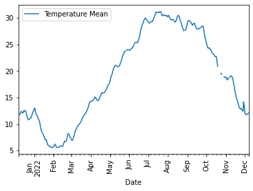

```python
temperature.plot.line(x='Date')
plt.xticks(rotation=90)
```

### Salinity

Salinity is the dissolved salt content of a body of water. It is a strong contributor to conductivity and helps determine many aspects of the chemistry of natural waters and the biological processes within them. Salinity, along with temperature and pressure, helps govern physical characteristics of water such as density and heat capacity.

```python
#sorting the water quality
water_qual = water_qual.rename(columns={'Salinity, water, unfiltered, parts per thousand (Maximum)': 'Salinity Max'})
water_qual = water_qual.rename(columns={'Salinity, water, unfiltered, parts per thousand (Minimum)': 'Salinity Min'})
water_qual = water_qual.rename(columns={'Salinity, water, unfiltered, parts per thousand (Mean)': 'Salinity Mean'})
water_qual
```

|  | Date | Turbidity Mean | Turbidity Max | Turbidity Min | Gage Height Max | Gage height, feet (Minimum) | Gage Height Mean | Temperature Max | Temperature Min | Temperature Mean | ... | Specific conductance, water, unfiltered, microsiemens per centimeter at 25 degrees Celsius (Mean) | Salinity Max | Salinity Min | Salinity Mean | pH, water, unfiltered, field, standard units (Maximum) | pH, water, unfiltered, field, standard units (Minimum) | pH, water, unfiltered, field, standard units (Median) | Discharge, cubic feet per second (Mean) | Dissolved oxygen, water, unfiltered, milligrams per liter (Mean) | Nitrate plus nitrite, water, in situ, milligrams per liter as nitrogen (Mean) |
| --- | --- | --- | --- | --- | --- | --- | --- | --- | --- | --- | --- | --- | --- | --- | --- | --- | --- | --- | --- | --- | --- |
| 1 | 2021-12-07 | 48.1 | 66.4 | 39.6 | 10.21 | 9.55 | 9.95 | 12.1 | 11.8 | 11.9 | ... | 442 | 0.2 | 0.2 | 0.2 | 8 | 7.9 | 8 | 286000 | 10.2 | 1.3 |
| 2 | 2021-12-08 | 28.9 | 47.3 | 22.3 | 9.67 | 9.07 | 9.48 | 11.9 | 11.6 | 11.8 | ... | 462 | 0.2 | 0.2 | 0.2 | 8 | 8 | 8 | 276000 | 10.3 | 1.31 |
| 3 | 2021-12-09 | 25.1 | 33.2 | 18.4 | 9.12 | 8.55 | 8.95 | 11.9 | 11.6 | 11.8 | ... | 461 | 0.2 | 0.2 | 0.2 | 8 | 8 | 8 | 264000 | 10.3 | 1.31 |
| 4 | 2021-12-10 | 24.8 | 34.3 | 19.1 | 8.58 | 8.32 | 8.49 | 12.3 | 11.9 | 12.1 | ... | 469 | 0.2 | 0.2 | 0.2 | 8 | 8 | 8 | 253000 | 10.2 | 1.27 |
| 5 | 2021-12-11 | 22.1 | 32.8 | 15.5 | 8.38 | 8.14 | 8.27 | 12.6 | 12.2 | 12.4 | ... | 474 | 0.3 | 0.2 | 0.2 | 8 | 8 | 8 | 248000 | 10.2 | 1.25 |
| ... | ... | ... | ... | ... | ... | ... | ... | ... | ... | ... | ... | ... | ... | ... | ... | ... | ... | ... | ... | ... | ... |
| 362 | 2022-12-03 | 21.2 | 23.5 | 19 | 8.66 | 8.35 | 8.49 | 11.9 | 11.7 | 11.8 | ... | 479 | 0.2 | 0.2 | 0.2 | 8.2 | 8.1 | 8.1 | 242000 | 10.5 | 0.8 |
| 363 | 2022-12-04 | 20.7 | 22.6 | 16.1 | 8.4 | 7.88 | 8.15 | 11.9 | 11.7 | 11.8 | ... | 461 | 0.2 | 0.2 | 0.2 | 8.1 | 8.1 | 8.1 | 233000 | 10.5 | 0.78 |
| 364 | 2022-12-05 | 23.1 | 33.3 | 18.1 | 7.97 | 7.59 | 7.79 | 12.1 | 11.8 | 11.9 | ... | 472 | 0.2 | 0.2 | 0.2 | 8.1 | 8.1 | 8.1 | 224000 | 10.4 | 0.77 |
| 365 | 2022-12-06 | 30.9 | 39.3 | 24.9 | 7.89 | 7.25 | 7.59 | 12.2 | 11.8 | 12 | ... | 471 | 0.2 | 0.2 | 0.2 | 8.1 | 8.1 | 8.1 | 219000 | 10.3 | 0.81 |
| 366 | 2022-12-07 | 31.8 | 36.6 | 27.9 | 7.59 | 7.08 | 7.36 | 12.3 | 11.9 | 12.1 | ... | 458 | 0.2 | 0.2 | 0.2 | 8.1 | 8.1 | 8.1 | 213000 | 10.3 | 0.82 |

366 rows × 22 columns

```python
salinity = water_qual.filter(['Date','Salinity Mean'], axis=1)
salinity
```

|  | Date | Salinity Mean |
| --- | --- | --- |
| 1 | 2021-12-07 | 0.2 |
| 2 | 2021-12-08 | 0.2 |
| 3 | 2021-12-09 | 0.2 |
| 4 | 2021-12-10 | 0.2 |
| 5 | 2021-12-11 | 0.2 |
| ... | ... | ... |
| 362 | 2022-12-03 | 0.2 |
| 363 | 2022-12-04 | 0.2 |
| 364 | 2022-12-05 | 0.2 |
| 365 | 2022-12-06 | 0.2 |
| 366 | 2022-12-07 | 0.2 |

366 rows × 2 columns

```python
salinity['Salinity Mean']=salinity['Salinity Mean'].astype(float)
```

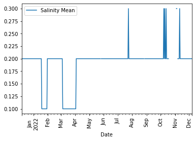

```python
salinity.plot.line(x='Date')
plt.xticks(rotation=90)
```

### pH

pH is a measure of how acidic/basic water is. The range goes from 0 to 14, with 7 being neutral. pHs of less than 7 indicate acidity, whereas a pH of greater than 7 indicates a base. pH is really a measure of the relative amount of free hydrogen and hydroxyl ions in the water. Water that has more free hydrogen ions is acidic, whereas water that has more free hydroxyl ions is basic. Since pH can be affected by chemicals in the water, pH is an important indicator of water that is changing chemically

```python
#sorting the water quality
water_qual = water_qual.rename(columns={'pH, water, unfiltered, field, standard units (Maximum)': 'pH Max'})
water_qual = water_qual.rename(columns={'pH, water, unfiltered, field, standard units (Minimum)': 'pH Min'})
water_qual = water_qual.rename(columns={'pH, water, unfiltered, field, standard units (Median)': 'pH Median'})
water_qual
```

|  | Date | Turbidity Mean | Turbidity Max | Turbidity Min | Gage Height Max | Gage height, feet (Minimum) | Gage Height Mean | Temperature Max | Temperature Min | Temperature Mean | ... | Specific conductance, water, unfiltered, microsiemens per centimeter at 25 degrees Celsius (Mean) | Salinity Max | Salinity Min | Salinity Mean | pH Max | pH Min | pH Median | Discharge, cubic feet per second (Mean) | Dissolved oxygen, water, unfiltered, milligrams per liter (Mean) | Nitrate plus nitrite, water, in situ, milligrams per liter as nitrogen (Mean) |
| --- | --- | --- | --- | --- | --- | --- | --- | --- | --- | --- | --- | --- | --- | --- | --- | --- | --- | --- | --- | --- | --- |
| 1 | 2021-12-07 | 48.1 | 66.4 | 39.6 | 10.21 | 9.55 | 9.95 | 12.1 | 11.8 | 11.9 | ... | 442 | 0.2 | 0.2 | 0.2 | 8 | 7.9 | 8 | 286000 | 10.2 | 1.3 |
| 2 | 2021-12-08 | 28.9 | 47.3 | 22.3 | 9.67 | 9.07 | 9.48 | 11.9 | 11.6 | 11.8 | ... | 462 | 0.2 | 0.2 | 0.2 | 8 | 8 | 8 | 276000 | 10.3 | 1.31 |
| 3 | 2021-12-09 | 25.1 | 33.2 | 18.4 | 9.12 | 8.55 | 8.95 | 11.9 | 11.6 | 11.8 | ... | 461 | 0.2 | 0.2 | 0.2 | 8 | 8 | 8 | 264000 | 10.3 | 1.31 |
| 4 | 2021-12-10 | 24.8 | 34.3 | 19.1 | 8.58 | 8.32 | 8.49 | 12.3 | 11.9 | 12.1 | ... | 469 | 0.2 | 0.2 | 0.2 | 8 | 8 | 8 | 253000 | 10.2 | 1.27 |
| 5 | 2021-12-11 | 22.1 | 32.8 | 15.5 | 8.38 | 8.14 | 8.27 | 12.6 | 12.2 | 12.4 | ... | 474 | 0.3 | 0.2 | 0.2 | 8 | 8 | 8 | 248000 | 10.2 | 1.25 |
| ... | ... | ... | ... | ... | ... | ... | ... | ... | ... | ... | ... | ... | ... | ... | ... | ... | ... | ... | ... | ... | ... |
| 362 | 2022-12-03 | 21.2 | 23.5 | 19 | 8.66 | 8.35 | 8.49 | 11.9 | 11.7 | 11.8 | ... | 479 | 0.2 | 0.2 | 0.2 | 8.2 | 8.1 | 8.1 | 242000 | 10.5 | 0.8 |
| 363 | 2022-12-04 | 20.7 | 22.6 | 16.1 | 8.4 | 7.88 | 8.15 | 11.9 | 11.7 | 11.8 | ... | 461 | 0.2 | 0.2 | 0.2 | 8.1 | 8.1 | 8.1 | 233000 | 10.5 | 0.78 |
| 364 | 2022-12-05 | 23.1 | 33.3 | 18.1 | 7.97 | 7.59 | 7.79 | 12.1 | 11.8 | 11.9 | ... | 472 | 0.2 | 0.2 | 0.2 | 8.1 | 8.1 | 8.1 | 224000 | 10.4 | 0.77 |
| 365 | 2022-12-06 | 30.9 | 39.3 | 24.9 | 7.89 | 7.25 | 7.59 | 12.2 | 11.8 | 12 | ... | 471 | 0.2 | 0.2 | 0.2 | 8.1 | 8.1 | 8.1 | 219000 | 10.3 | 0.81 |
| 366 | 2022-12-07 | 31.8 | 36.6 | 27.9 | 7.59 | 7.08 | 7.36 | 12.3 | 11.9 | 12.1 | ... | 458 | 0.2 | 0.2 | 0.2 | 8.1 | 8.1 | 8.1 | 213000 | 10.3 | 0.82 |

366 rows × 22 columns

```python
pH = water_qual.filter(['Date','pH Median'], axis=1)
pH
```

|  | Date | pH Median |
| --- | --- | --- |
| 1 | 2021-12-07 | 8 |
| 2 | 2021-12-08 | 8 |
| 3 | 2021-12-09 | 8 |
| 4 | 2021-12-10 | 8 |
| 5 | 2021-12-11 | 8 |
| ... | ... | ... |
| 362 | 2022-12-03 | 8.1 |
| 363 | 2022-12-04 | 8.1 |
| 364 | 2022-12-05 | 8.1 |
| 365 | 2022-12-06 | 8.1 |
| 366 | 2022-12-07 | 8.1 |

366 rows × 2 columns

```python
pH['pH Median']=pH['pH Median'].astype(float)
```

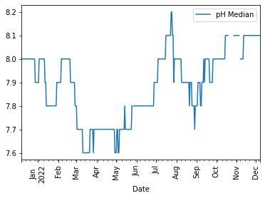

```python
pH.plot.line(x='Date')
plt.xticks(rotation=90)
```

### Discharge

Discharge, also called water flow, is defined as the rate at which a volume of water passes by a particular location.

```python
#sorting the water quality
water_qual = water_qual.rename(columns={'Discharge, cubic feet per second (Mean)': 'Discharge'})
water_qual
```

|  | Date | Turbidity Mean | Turbidity Max | Turbidity Min | Gage Height Max | Gage height, feet (Minimum) | Gage Height Mean | Temperature Max | Temperature Min | Temperature Mean | ... | Specific conductance, water, unfiltered, microsiemens per centimeter at 25 degrees Celsius (Mean) | Salinity Max | Salinity Min | Salinity Mean | pH Max | pH Min | pH Median | Discharge | Dissolved oxygen, water, unfiltered, milligrams per liter (Mean) | Nitrate plus nitrite, water, in situ, milligrams per liter as nitrogen (Mean) |
| --- | --- | --- | --- | --- | --- | --- | --- | --- | --- | --- | --- | --- | --- | --- | --- | --- | --- | --- | --- | --- | --- |
| 1 | 2021-12-07 | 48.1 | 66.4 | 39.6 | 10.21 | 9.55 | 9.95 | 12.1 | 11.8 | 11.9 | ... | 442 | 0.2 | 0.2 | 0.2 | 8 | 7.9 | 8 | 286000 | 10.2 | 1.3 |
| 2 | 2021-12-08 | 28.9 | 47.3 | 22.3 | 9.67 | 9.07 | 9.48 | 11.9 | 11.6 | 11.8 | ... | 462 | 0.2 | 0.2 | 0.2 | 8 | 8 | 8 | 276000 | 10.3 | 1.31 |
| 3 | 2021-12-09 | 25.1 | 33.2 | 18.4 | 9.12 | 8.55 | 8.95 | 11.9 | 11.6 | 11.8 | ... | 461 | 0.2 | 0.2 | 0.2 | 8 | 8 | 8 | 264000 | 10.3 | 1.31 |
| 4 | 2021-12-10 | 24.8 | 34.3 | 19.1 | 8.58 | 8.32 | 8.49 | 12.3 | 11.9 | 12.1 | ... | 469 | 0.2 | 0.2 | 0.2 | 8 | 8 | 8 | 253000 | 10.2 | 1.27 |
| 5 | 2021-12-11 | 22.1 | 32.8 | 15.5 | 8.38 | 8.14 | 8.27 | 12.6 | 12.2 | 12.4 | ... | 474 | 0.3 | 0.2 | 0.2 | 8 | 8 | 8 | 248000 | 10.2 | 1.25 |
| ... | ... | ... | ... | ... | ... | ... | ... | ... | ... | ... | ... | ... | ... | ... | ... | ... | ... | ... | ... | ... | ... |
| 362 | 2022-12-03 | 21.2 | 23.5 | 19 | 8.66 | 8.35 | 8.49 | 11.9 | 11.7 | 11.8 | ... | 479 | 0.2 | 0.2 | 0.2 | 8.2 | 8.1 | 8.1 | 242000 | 10.5 | 0.8 |
| 363 | 2022-12-04 | 20.7 | 22.6 | 16.1 | 8.4 | 7.88 | 8.15 | 11.9 | 11.7 | 11.8 | ... | 461 | 0.2 | 0.2 | 0.2 | 8.1 | 8.1 | 8.1 | 233000 | 10.5 | 0.78 |
| 364 | 2022-12-05 | 23.1 | 33.3 | 18.1 | 7.97 | 7.59 | 7.79 | 12.1 | 11.8 | 11.9 | ... | 472 | 0.2 | 0.2 | 0.2 | 8.1 | 8.1 | 8.1 | 224000 | 10.4 | 0.77 |
| 365 | 2022-12-06 | 30.9 | 39.3 | 24.9 | 7.89 | 7.25 | 7.59 | 12.2 | 11.8 | 12 | ... | 471 | 0.2 | 0.2 | 0.2 | 8.1 | 8.1 | 8.1 | 219000 | 10.3 | 0.81 |
| 366 | 2022-12-07 | 31.8 | 36.6 | 27.9 | 7.59 | 7.08 | 7.36 | 12.3 | 11.9 | 12.1 | ... | 458 | 0.2 | 0.2 | 0.2 | 8.1 | 8.1 | 8.1 | 213000 | 10.3 | 0.82 |

366 rows × 22 columns

```python
discharge = water_qual.filter(['Date','Discharge'], axis=1)
discharge
```

|  | Date | Discharge |
| --- | --- | --- |
| 1 | 2021-12-07 | 286000 |
| 2 | 2021-12-08 | 276000 |
| 3 | 2021-12-09 | 264000 |
| 4 | 2021-12-10 | 253000 |
| 5 | 2021-12-11 | 248000 |
| ... | ... | ... |
| 362 | 2022-12-03 | 242000 |
| 363 | 2022-12-04 | 233000 |
| 364 | 2022-12-05 | 224000 |
| 365 | 2022-12-06 | 219000 |
| 366 | 2022-12-07 | 213000 |

366 rows × 2 columns

```python
discharge['Discharge']=discharge['Discharge'].astype(float)
```

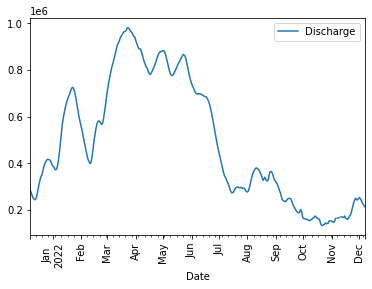

```python
discharge.plot.line(x='Date')
plt.xticks(rotation=90)
```

### Dissolved Oxygen

Dissolved oxygen is a measure of how much oxygen is dissolved in the water

```python
#sorting the water quality
water_qual = water_qual.rename(columns={'Dissolved oxygen, water, unfiltered, milligrams per liter (Mean)': 'Dissolved Oxygen'})
water_qual
```

|  | Date | Turbidity Mean | Turbidity Max | Turbidity Min | Gage Height Max | Gage height, feet (Minimum) | Gage Height Mean | Temperature Max | Temperature Min | Temperature Mean | ... | Specific conductance, water, unfiltered, microsiemens per centimeter at 25 degrees Celsius (Mean) | Salinity Max | Salinity Min | Salinity Mean | pH Max | pH Min | pH Median | Discharge | Dissolved Oxygen | Nitrate plus nitrite, water, in situ, milligrams per liter as nitrogen (Mean) |
| --- | --- | --- | --- | --- | --- | --- | --- | --- | --- | --- | --- | --- | --- | --- | --- | --- | --- | --- | --- | --- | --- |
| 1 | 2021-12-07 | 48.1 | 66.4 | 39.6 | 10.21 | 9.55 | 9.95 | 12.1 | 11.8 | 11.9 | ... | 442 | 0.2 | 0.2 | 0.2 | 8 | 7.9 | 8 | 286000 | 10.2 | 1.3 |
| 2 | 2021-12-08 | 28.9 | 47.3 | 22.3 | 9.67 | 9.07 | 9.48 | 11.9 | 11.6 | 11.8 | ... | 462 | 0.2 | 0.2 | 0.2 | 8 | 8 | 8 | 276000 | 10.3 | 1.31 |
| 3 | 2021-12-09 | 25.1 | 33.2 | 18.4 | 9.12 | 8.55 | 8.95 | 11.9 | 11.6 | 11.8 | ... | 461 | 0.2 | 0.2 | 0.2 | 8 | 8 | 8 | 264000 | 10.3 | 1.31 |
| 4 | 2021-12-10 | 24.8 | 34.3 | 19.1 | 8.58 | 8.32 | 8.49 | 12.3 | 11.9 | 12.1 | ... | 469 | 0.2 | 0.2 | 0.2 | 8 | 8 | 8 | 253000 | 10.2 | 1.27 |
| 5 | 2021-12-11 | 22.1 | 32.8 | 15.5 | 8.38 | 8.14 | 8.27 | 12.6 | 12.2 | 12.4 | ... | 474 | 0.3 | 0.2 | 0.2 | 8 | 8 | 8 | 248000 | 10.2 | 1.25 |
| ... | ... | ... | ... | ... | ... | ... | ... | ... | ... | ... | ... | ... | ... | ... | ... | ... | ... | ... | ... | ... | ... |
| 362 | 2022-12-03 | 21.2 | 23.5 | 19 | 8.66 | 8.35 | 8.49 | 11.9 | 11.7 | 11.8 | ... | 479 | 0.2 | 0.2 | 0.2 | 8.2 | 8.1 | 8.1 | 242000 | 10.5 | 0.8 |
| 363 | 2022-12-04 | 20.7 | 22.6 | 16.1 | 8.4 | 7.88 | 8.15 | 11.9 | 11.7 | 11.8 | ... | 461 | 0.2 | 0.2 | 0.2 | 8.1 | 8.1 | 8.1 | 233000 | 10.5 | 0.78 |
| 364 | 2022-12-05 | 23.1 | 33.3 | 18.1 | 7.97 | 7.59 | 7.79 | 12.1 | 11.8 | 11.9 | ... | 472 | 0.2 | 0.2 | 0.2 | 8.1 | 8.1 | 8.1 | 224000 | 10.4 | 0.77 |
| 365 | 2022-12-06 | 30.9 | 39.3 | 24.9 | 7.89 | 7.25 | 7.59 | 12.2 | 11.8 | 12 | ... | 471 | 0.2 | 0.2 | 0.2 | 8.1 | 8.1 | 8.1 | 219000 | 10.3 | 0.81 |
| 366 | 2022-12-07 | 31.8 | 36.6 | 27.9 | 7.59 | 7.08 | 7.36 | 12.3 | 11.9 | 12.1 | ... | 458 | 0.2 | 0.2 | 0.2 | 8.1 | 8.1 | 8.1 | 213000 | 10.3 | 0.82 |

366 rows × 22 columns

```python
oxygen = water_qual.filter(['Date','Dissolved Oxygen'], axis=1)
oxygen
```

|  | Date | Dissolved Oxygen |
| --- | --- | --- |
| 1 | 2021-12-07 | 10.2 |
| 2 | 2021-12-08 | 10.3 |
| 3 | 2021-12-09 | 10.3 |
| 4 | 2021-12-10 | 10.2 |
| 5 | 2021-12-11 | 10.2 |
| ... | ... | ... |
| 362 | 2022-12-03 | 10.5 |
| 363 | 2022-12-04 | 10.5 |
| 364 | 2022-12-05 | 10.4 |
| 365 | 2022-12-06 | 10.3 |
| 366 | 2022-12-07 | 10.3 |

366 rows × 2 columns

```python
oxygen['Dissolved Oxygen']=oxygen['Dissolved Oxygen'].astype(float)
```

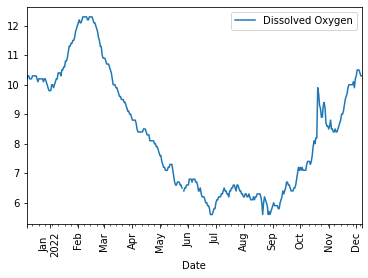

```python
oxygen.plot.line(x='Date')
plt.xticks(rotation=90)
```

### Nitrate

Nutrients, such as nitrogen and phosphorus, are essential for plant and animal growth and nourishment, but the overabundance of certain nutrients in water can cause a number of adverse health and ecological effects. Nitrogen, in the forms of nitrate, nitrite, or ammonium, is a nutrient needed for plant growth. About 78% of the air that we breathe is composed of nitrogen gas, and in some areas of the United States, particularly the northeast, certain forms of nitrogen are commonly deposited in acid rain.

```python
#sorting the water quality
water_qual = water_qual.rename(columns={'Nitrate plus nitrite, water, in situ, milligrams per liter as nitrogen (Mean)': 'Nitrate'})
water_qual
```

|  | Date | Turbidity Mean | Turbidity Max | Turbidity Min | Gage Height Max | Gage height, feet (Minimum) | Gage Height Mean | Temperature Max | Temperature Min | Temperature Mean | ... | Specific conductance, water, unfiltered, microsiemens per centimeter at 25 degrees Celsius (Mean) | Salinity Max | Salinity Min | Salinity Mean | pH Max | pH Min | pH Median | Discharge | Dissolved Oxygen | Nitrate |
| --- | --- | --- | --- | --- | --- | --- | --- | --- | --- | --- | --- | --- | --- | --- | --- | --- | --- | --- | --- | --- | --- |
| 1 | 2021-12-07 | 48.1 | 66.4 | 39.6 | 10.21 | 9.55 | 9.95 | 12.1 | 11.8 | 11.9 | ... | 442 | 0.2 | 0.2 | 0.2 | 8 | 7.9 | 8 | 286000 | 10.2 | 1.3 |
| 2 | 2021-12-08 | 28.9 | 47.3 | 22.3 | 9.67 | 9.07 | 9.48 | 11.9 | 11.6 | 11.8 | ... | 462 | 0.2 | 0.2 | 0.2 | 8 | 8 | 8 | 276000 | 10.3 | 1.31 |
| 3 | 2021-12-09 | 25.1 | 33.2 | 18.4 | 9.12 | 8.55 | 8.95 | 11.9 | 11.6 | 11.8 | ... | 461 | 0.2 | 0.2 | 0.2 | 8 | 8 | 8 | 264000 | 10.3 | 1.31 |
| 4 | 2021-12-10 | 24.8 | 34.3 | 19.1 | 8.58 | 8.32 | 8.49 | 12.3 | 11.9 | 12.1 | ... | 469 | 0.2 | 0.2 | 0.2 | 8 | 8 | 8 | 253000 | 10.2 | 1.27 |
| 5 | 2021-12-11 | 22.1 | 32.8 | 15.5 | 8.38 | 8.14 | 8.27 | 12.6 | 12.2 | 12.4 | ... | 474 | 0.3 | 0.2 | 0.2 | 8 | 8 | 8 | 248000 | 10.2 | 1.25 |
| ... | ... | ... | ... | ... | ... | ... | ... | ... | ... | ... | ... | ... | ... | ... | ... | ... | ... | ... | ... | ... | ... |
| 362 | 2022-12-03 | 21.2 | 23.5 | 19 | 8.66 | 8.35 | 8.49 | 11.9 | 11.7 | 11.8 | ... | 479 | 0.2 | 0.2 | 0.2 | 8.2 | 8.1 | 8.1 | 242000 | 10.5 | 0.8 |
| 363 | 2022-12-04 | 20.7 | 22.6 | 16.1 | 8.4 | 7.88 | 8.15 | 11.9 | 11.7 | 11.8 | ... | 461 | 0.2 | 0.2 | 0.2 | 8.1 | 8.1 | 8.1 | 233000 | 10.5 | 0.78 |
| 364 | 2022-12-05 | 23.1 | 33.3 | 18.1 | 7.97 | 7.59 | 7.79 | 12.1 | 11.8 | 11.9 | ... | 472 | 0.2 | 0.2 | 0.2 | 8.1 | 8.1 | 8.1 | 224000 | 10.4 | 0.77 |
| 365 | 2022-12-06 | 30.9 | 39.3 | 24.9 | 7.89 | 7.25 | 7.59 | 12.2 | 11.8 | 12 | ... | 471 | 0.2 | 0.2 | 0.2 | 8.1 | 8.1 | 8.1 | 219000 | 10.3 | 0.81 |
| 366 | 2022-12-07 | 31.8 | 36.6 | 27.9 | 7.59 | 7.08 | 7.36 | 12.3 | 11.9 | 12.1 | ... | 458 | 0.2 | 0.2 | 0.2 | 8.1 | 8.1 | 8.1 | 213000 | 10.3 | 0.82 |

366 rows × 22 columns

```python
nitrate = water_qual.filter(['Date', 'Nitrate'], axis=1)
nitrate.dropna()
nitrate
```

|  | Date | Nitrate |
| --- | --- | --- |
| 1 | 2021-12-07 | 1.3 |
| 2 | 2021-12-08 | 1.31 |
| 3 | 2021-12-09 | 1.31 |
| 4 | 2021-12-10 | 1.27 |
| 5 | 2021-12-11 | 1.25 |
| ... | ... | ... |
| 362 | 2022-12-03 | 0.8 |
| 363 | 2022-12-04 | 0.78 |
| 364 | 2022-12-05 | 0.77 |
| 365 | 2022-12-06 | 0.81 |
| 366 | 2022-12-07 | 0.82 |

366 rows × 2 columns

```python
nitrate['Nitrate']=nitrate['Nitrate'].astype(float)
```

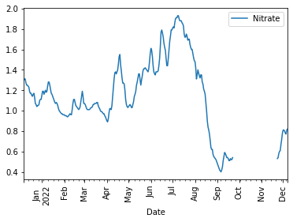

```python
nitrate.plot.line(x='Date')
plt.xticks(rotation=90)
```

# Comparisons

### Methane Gas

Methane, a hydrocarbon, is an extremely potent greenhouse gas that contributes the the effects of climate change. It is 25 times more powerful than CO2 at trapping heat in the atmosphere and is generated by a multitude of sources such as fossil fuel production, transportation, and decay. Not only does it warm the planet at a rapid rate, but it reduces the amount of oxygen in the air contributing to harmful effects for both humans and the environment. It is estimated that exposure to ground-level ozone, which is formed by methane, causes around 1 million premature deaths around the world each year.

Started by joining the data of the Mean Methane per day with the tons of barge movements.

```python
#join mean methane per day and tons per day into a dataframe so we can graph
methaneTonsPerDayJoin = tonsPerDay.join(meanMethanePerDay, lsuffix="Date", how='outer')
```

```python
methaneTonsPerDayJoin["Tons"] = tonsPerDay

# removing Missing Values
methaneTonsPerDayJoin.dropna(inplace=True)

methaneTonsPerDayJoin.head(10)
```

|  | Tons | Methane |
| --- | --- | --- |
| 2020-06-27 | 868840.0 | 2.120000 |
| 2020-07-04 | 658856.0 | 2.914583 |
| 2020-07-11 | 824916.0 | 4.277083 |
| 2020-07-18 | 746792.0 | 2.190000 |
| 2020-07-25 | 838643.0 | 1.940000 |
| 2020-08-01 | 890050.0 | 6.015833 |
| 2020-08-08 | 626068.0 | 5.404545 |
| 2020-08-15 | 921810.0 | 8.136667 |
| 2020-08-22 | 921644.0 | 4.356250 |
| 2020-08-29 | 759740.0 | 6.309167 |

We then scaled the values to provide a better visual comparison between the two variables

```python
import seaborn as sns
from sklearn.preprocessing import MinMaxScaler
import pandas as pd

scaler = MinMaxScaler()

meth_scaled = scaler.fit_transform(methaneTonsPerDayJoin.to_numpy())
meth_scaled = pd.DataFrame(meth_scaled, columns=['Tons', 'Methane'])

print("Scaled Dataset Using MinMaxScaler")
meth_scaled.head()
```

```
Scaled Dataset Using MinMaxScaler
```

|  | Tons | Methane |
| --- | --- | --- |
| 0 | 0.512689 | 0.029048 |
| 1 | 0.262174 | 0.157275 |
| 2 | 0.460287 | 0.377152 |
| 3 | 0.367083 | 0.040344 |
| 4 | 0.476663 | 0.000000 |

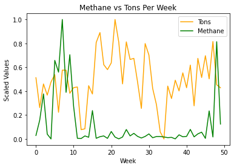

```python
plt.figure(figsize=(16, 8), dpi=150)

# we have passed colors as a list
meth_scaled.plot(label='Methane', color=['orange', 'green'])

# adding title
plt.title('Methane vs Tons Per Week')

# adding label to x-axis
plt.xlabel('Week')
plt.ylabel('Scaled Values')

# adding legend.
plt.legend()
```

```python
methaneTonsPerDayJoin.corr()
```

|  | Tons | Methane |
| --- | --- | --- |
| Tons | 1.000000 | -0.073034 |
| Methane | -0.073034 | 1.000000 |

As we can see here, there is no real correlation between methane and barge movements. From our previous research we have seen that cows make up most of the methane gas makeup in the environment, so this value shows no significance to our results.

### Sulfur Dioxide Comparison

```python
#join mean Sulfur Dioxide per day and tons per day into a dataframe so we can graph
SDTonsPerDayJoin = tonsPerDay.join(meanSDPerDay, lsuffix="Date", how='outer')
```

```python
SDTonsPerDayJoin["Tons"] = tonsPerDay

# removing Missing Values
SDTonsPerDayJoin.dropna(inplace=True)

SDTonsPerDayJoin.head(10)
```

|  | Tons | SulfurDioxide |
| --- | --- | --- |
| 2020-06-27 | 868840.0 | 0.004167 |
| 2020-07-04 | 658856.0 | 2.900000 |
| 2020-07-11 | 824916.0 | 0.712500 |
| 2020-07-18 | 746792.0 | 0.104167 |
| 2020-07-25 | 838643.0 | 0.095833 |
| 2020-08-01 | 890050.0 | 0.170833 |
| 2020-08-08 | 626068.0 | 0.329167 |
| 2020-08-15 | 921810.0 | 0.795833 |
| 2020-08-22 | 921644.0 | 0.520833 |
| 2020-08-29 | 759740.0 | 0.504167 |

```python
scaler = MinMaxScaler()

SD_scaled = scaler.fit_transform(SDTonsPerDayJoin.to_numpy())
SD_scaled = pd.DataFrame(SD_scaled, columns=['Tons', 'SulfurDioxide'])

print("Scaled Dataset Using MinMaxScaler")
SD_scaled.head()
```

```
Scaled Dataset Using MinMaxScaler
```

|  | Tons | SulfurDioxide |
| --- | --- | --- |
| 0 | 0.512689 | 0.000000 |
| 1 | 0.262174 | 1.000000 |
| 2 | 0.460287 | 0.244604 |
| 3 | 0.367083 | 0.034532 |
| 4 | 0.476663 | 0.031655 |

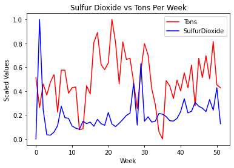

```python
plt.figure(figsize=(16, 8), dpi=150)

# we have passed colors as a list
SD_scaled.plot(label='SulfurDioxide', color=['red', 'blue'])

# adding title
plt.title('Sulfur Dioxide vs Tons Per Week')

# adding label to x-axis
plt.xlabel('Week')
plt.ylabel('Scaled Values')

# adding legend.
plt.legend()
```

```python
SDTonsPerDayJoin.corr()
```

|  | Tons | SulfurDioxide |
| --- | --- | --- |
| Tons | 1.000000 | -0.072108 |
| SulfurDioxide | -0.072108 | 1.000000 |

Again, we see that there is no correlation between sulfur dioxide and barge movements. The correlation is negative, meaning that this chemical is not impacted by barge movements.

### Hydrogen Sulfide Comparison

Exposure to hydrogen sulfide may cause irritation to the eyes and respiratory system. It can also cause apnea, coma, convulsions; dizziness, headache, weakness, irritability, insomnia; stomach upset, and if liquid: frostbite. Workers may be harmed from exposure to hydrogen sulfide. The level of exposure depends upon the dose, duration, and work being done.

```python
#join mean Sulfur Dioxide per day and tons per day into a dataframe so we can graph
HSTonsPerDayJoin = tonsPerDay.join(meanHSPerDay, lsuffix="Date", how='outer')
```

```python
HSTonsPerDayJoin["Tons"] = tonsPerDay

# removing Missing Values
HSTonsPerDayJoin.dropna(inplace=True)

HSTonsPerDayJoin.head(10)
```

|  | Tons | HydrogenSulfide |
| --- | --- | --- |
| 2020-06-27 | 868840.0 | 1.541667 |
| 2020-07-04 | 658856.0 | 1.416667 |
| 2020-07-11 | 824916.0 | 1.583333 |
| 2020-07-18 | 746792.0 | 1.458333 |
| 2020-07-25 | 838643.0 | 1.583333 |
| 2020-08-01 | 890050.0 | 3.375000 |
| 2020-08-08 | 626068.0 | 3.250000 |
| 2020-08-15 | 921810.0 | 4.958333 |
| 2020-08-22 | 921644.0 | 1.916667 |
| 2020-08-29 | 759740.0 | 3.541667 |

```python
scaler = MinMaxScaler()

HS_scaled = scaler.fit_transform(HSTonsPerDayJoin.to_numpy())
HS_scaled = pd.DataFrame(HS_scaled, columns=['Tons', 'HydrogenSulfide'])

print("Scaled Dataset Using MinMaxScaler")
HS_scaled.head()
```

```
Scaled Dataset Using MinMaxScaler
```

|  | Tons | HydrogenSulfide |
| --- | --- | --- |
| 0 | 0.512689 | 0.196078 |
| 1 | 0.262174 | 0.166667 |
| 2 | 0.460287 | 0.205882 |
| 3 | 0.367083 | 0.176471 |
| 4 | 0.476663 | 0.205882 |

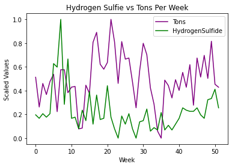

```python
plt.figure(figsize=(16, 8), dpi=150)

# we have passed colors as a list
HS_scaled.plot(label='HydrogenSulfide', color=['purple', 'green'])

# adding title
plt.title('Hydrogen Sulfie vs Tons Per Week')

# adding label to x-axis
plt.xlabel('Week')
plt.ylabel('Scaled Values')

# adding legend.
plt.legend()
```

```python
HSTonsPerDayJoin.corr()
```

|  | Tons | HydrogenSulfide |
| --- | --- | --- |
| Tons | 1.000000 | 0.073799 |
| HydrogenSulfide | 0.073799 | 1.000000 |

### Particulate Matter Comparison

If the level goes to or above 35 μg/m3 during a 24-hour period, the air is considered unhealthy and can cause issues for people with existing breathing issues such as asthma. Prolonged exposure to levels above 50 μg/m3 can lead to serious health issues and premature mortality. Particulate matter exposure to fine particles can also affect lung function and worsen medical conditions such as asthma and heart disease. Scientific studies have linked increases in daily PM2.5 exposure with increased respiratory and cardiovascular hospital admissions, emergency department visits and deaths.

```python
#join mean Particulate Matter per day and tons per day into a dataframe so we can graph
PMTonsPerDayJoin = tonsPerDay.join(meanPMPerDay, lsuffix="Date", how='outer')
```

```python
PMTonsPerDayJoin["Tons"] = tonsPerDay

# removing Missing Values
PMTonsPerDayJoin.dropna(inplace=True)

PMTonsPerDayJoin.head(10)
```

|  | Tons | PM |
| --- | --- | --- |
| 2020-06-27 | 868840.0 | 14.950000 |
| 2020-07-04 | 658856.0 | 25.182609 |
| 2020-07-11 | 824916.0 | 17.808333 |
| 2020-07-18 | 746792.0 | 12.758333 |
| 2020-07-25 | 838643.0 | 6.808333 |
| 2020-08-01 | 890050.0 | 12.670833 |
| 2020-08-08 | 626068.0 | 12.200000 |
| 2020-08-15 | 921810.0 | 4.500000 |
| 2020-08-22 | 921644.0 | 12.837500 |
| 2020-08-29 | 759740.0 | 6.400000 |

```python
scaler = MinMaxScaler()

PM_scaled = scaler.fit_transform(PMTonsPerDayJoin.to_numpy())
PM_scaled = pd.DataFrame(PM_scaled, columns=['Tons', 'ParticulateMatter'])

print("Scaled Dataset Using MinMaxScaler")
PM_scaled.head()
```

```
Scaled Dataset Using MinMaxScaler
```

|  | Tons | ParticulateMatter |
| --- | --- | --- |
| 0 | 0.512689 | 0.515600 |
| 1 | 0.262174 | 1.000000 |
| 2 | 0.460287 | 0.650910 |
| 3 | 0.367083 | 0.411848 |
| 4 | 0.476663 | 0.130182 |

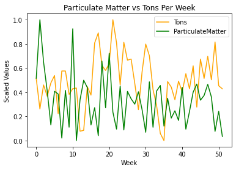

```python
plt.figure(figsize=(16, 8), dpi=150)

# we have passed colors as a list
PM_scaled.plot(label='ParticulateMatter', color=['orange', 'green'])

# adding title
plt.title('Particulate Matter vs Tons Per Week')

# adding label to x-axis
plt.xlabel('Week')
plt.ylabel('Scaled Values')

# adding legend.
plt.legend()
```

```python
PMTonsPerDayJoin.corr()
```

|  | Tons | PM |
| --- | --- | --- |
| Tons | 1.000000 | -0.231036 |
| PM | -0.231036 | 1.000000 |

### Turbidity comparison

High concentrations of particulate matter affect light penetration and ecological productivity, recreational values, and habitat quality, and cause lakes to fill in faster. In streams, increased sedimentation and siltation can occur, which can result in harm to habitat areas for fish and other aquatic life. Particles also provide attachment places for other pollutants, notably metals and bacteria. Turbidity values can be used as an indicator of potential pollution in a water body. If not removed, the causes of high turbidity can promote regrowth of pathogens in the water, leading to waterborne disease outbreaks, which we have seen in New Orleans quite often with water boil advisories.

```python
#join mean Turbidity per day and tons per day into a dataframe so we can graph
TTonsPerDayJoin = pd.merge(tonsPerDay, turbidity, how='outer', on='Date')
```

```python
# removing Missing Values
TTonsPerDayJoin.dropna(inplace=True)
TTonsPerDayJoin.head()
```

|  | Date | Tons | Turbidity Mean |
| --- | --- | --- | --- |
| 988 | 2021-12-11 | 836790.0 | 22.1 |
| 989 | 2021-12-18 | 822326.0 | 26.1 |
| 990 | 2021-12-25 | 624640.0 | 53.3 |
| 991 | 2022-01-01 | 626084.0 | 54.0 |
| 992 | 2022-01-08 | 544656.0 | 48.1 |

```python
TTonsPerDayJoin.set_index('Date')
```

| Date | Tons | Turbidity Mean |
| --- | --- | --- |
| 2021-12-11 | 836790.0 | 22.1 |
| 2021-12-18 | 822326.0 | 26.1 |
| 2021-12-25 | 624640.0 | 53.3 |
| 2022-01-01 | 626084.0 | 54.0 |
| 2022-01-08 | 544656.0 | 48.1 |
| 2022-01-15 | 491988.0 | 129.0 |
| 2022-01-22 | 775228.0 | 97.8 |
| 2022-01-29 | 489344.0 | 72.1 |
| 2022-02-05 | 581372.0 | 49.0 |
| 2022-02-12 | 426016.0 | 45.9 |
| 2022-02-19 | 540250.0 | 83.4 |
| 2022-02-26 | 533744.0 | 88.7 |
| 2022-03-05 | 634100.0 | 140.0 |
| 2022-03-12 | 567522.0 | 72.8 |
| 2022-03-19 | 693000.0 | 46.7 |
| 2022-03-26 | 805372.0 | 45.2 |
| 2022-04-02 | 660750.0 | 43.2 |
| 2022-04-09 | 765900.0 | 72.3 |
| 2022-04-16 | 870418.0 | 74.4 |
| 2022-04-23 | 895067.0 | 68.3 |
| 2022-04-30 | 790572.0 | 44.4 |
| 2022-05-07 | 894250.0 | 45.1 |
| 2022-05-14 | 835730.0 | 59.7 |
| 2022-05-21 | 711200.0 | 60.6 |
| 2022-05-28 | 947300.0 | 48.0 |
| 2022-06-04 | 583551.0 | 53.9 |
| 2022-06-11 | 828930.0 | 54.3 |
| 2022-06-18 | 769450.0 | 84.0 |
| 2022-06-25 | 619210.0 | 64.1 |
| 2022-07-02 | 932872.0 | 51.2 |
| 2022-07-09 | 727500.0 | 30.0 |
| 2022-07-16 | 709790.0 | 19.1 |
| 2022-07-23 | 564672.0 | 20.4 |
| 2022-07-30 | 731275.0 | 21.7 |
| 2022-08-06 | 753326.0 | 36.1 |
| 2022-08-13 | 537618.0 | 46.0 |
| 2022-08-20 | 360585.0 | 46.1 |
| 2022-09-03 | 240500.0 | 18.9 |
| 2022-09-10 | 249727.0 | 18.4 |
| 2022-09-17 | 209600.0 | 14.5 |
| 2022-09-24 | 220300.0 | 13.1 |
| 2022-10-01 | 316850.0 | 19.7 |

```python
TTonsPerDayJoin['Date'] = pd.to_numeric(pd.to_datetime(TTonsPerDayJoin['Date']))

scaler = MinMaxScaler()

T_scaled = scaler.fit_transform(TTonsPerDayJoin.to_numpy())
T_scaled = pd.DataFrame(T_scaled, columns=['Date','Tons', 'Oxygen'])

print("Scaled Dataset Using MinMaxScaler")
T_scaled.head()
```

```
Scaled Dataset Using MinMaxScaler
```

|  | Date | Tons | Oxygen |
| --- | --- | --- | --- |
| 0 | 0.000000 | 0.850197 | 0.070922 |
| 1 | 0.023810 | 0.830590 | 0.102443 |
| 2 | 0.047619 | 0.562614 | 0.316785 |
| 3 | 0.071429 | 0.564571 | 0.322301 |
| 4 | 0.095238 | 0.454190 | 0.275808 |

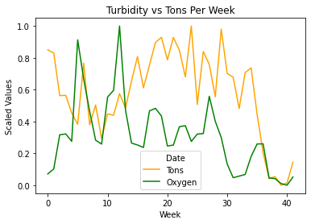

```python
plt.figure(figsize=(16, 8), dpi=150)

# we have passed colors as a list
T_scaled.plot(label='Turbidity', color=['white', 'orange', 'green'])

# adding title
plt.title('Turbidity vs Tons Per Week')

# adding label to x-axis
plt.xlabel('Week')
plt.ylabel('Scaled Values')

# adding legend.
plt.legend()
```

### Gage Height Comparison

Gage height is used to predict floods. Flood stage, officially defined by the National Weather Service, can be thought of as the stage (or gage height) at which overflow of the natural banks of a stream begins to cause damage in the local area from flooding. The National Weather Service uses gage height numbers to tell the public about different levels of flooding hazard.

```python
#join mean Gage Height per day and tons per day into a dataframe so we can graph
GHTonsPerDayJoin = pd.merge(tonsPerDay, gageHeight, how='outer', on='Date')
```

```python
# removing Missing Values
GHTonsPerDayJoin.dropna(inplace=True)

GHTonsPerDayJoin.head(10)
```

|  | Date | Tons | Gage Height Mean |
| --- | --- | --- | --- |
| 988 | 2021-12-11 | 836790.0 | 8.27 |
| 989 | 2021-12-18 | 822326.0 | 12.02 |
| 990 | 2021-12-25 | 624640.0 | 15.85 |
| 991 | 2022-01-01 | 626084.0 | 14.63 |
| 992 | 2022-01-08 | 544656.0 | 17.46 |
| 993 | 2022-01-15 | 491988.0 | 26.90 |
| 994 | 2022-01-22 | 775228.0 | 29.44 |
| 995 | 2022-01-29 | 489344.0 | 24.95 |
| 996 | 2022-02-05 | 581372.0 | 18.70 |
| 997 | 2022-02-12 | 426016.0 | 15.94 |

```python
GHTonsPerDayJoin.set_index('Date')
```

| Date | Tons | Gage Height Mean |
| --- | --- | --- |
| 2021-12-11 | 836790.0 | 8.27 |
| 2021-12-18 | 822326.0 | 12.02 |
| 2021-12-25 | 624640.0 | 15.85 |
| 2022-01-01 | 626084.0 | 14.63 |
| 2022-01-08 | 544656.0 | 17.46 |
| 2022-01-15 | 491988.0 | 26.90 |
| 2022-01-22 | 775228.0 | 29.44 |
| 2022-01-29 | 489344.0 | 24.95 |
| 2022-02-05 | 581372.0 | 18.70 |
| 2022-02-12 | 426016.0 | 15.94 |
| 2022-02-19 | 540250.0 | 23.66 |
| 2022-02-26 | 533744.0 | 25.31 |
| 2022-03-05 | 634100.0 | 31.15 |
| 2022-03-12 | 567522.0 | 33.92 |
| 2022-03-19 | 693000.0 | 35.27 |
| 2022-03-26 | 805372.0 | 35.44 |
| 2022-04-02 | 660750.0 | 34.22 |
| 2022-04-09 | 765900.0 | 32.71 |
| 2022-04-16 | 870418.0 | 31.00 |
| 2022-04-23 | 895067.0 | 32.19 |
| 2022-04-30 | 790572.0 | 33.34 |
| 2022-05-07 | 894250.0 | 31.64 |
| 2022-05-14 | 835730.0 | 31.27 |
| 2022-05-21 | 711200.0 | 32.67 |
| 2022-05-28 | 947300.0 | 31.59 |
| 2022-06-04 | 583551.0 | 29.16 |
| 2022-06-11 | 828930.0 | 28.64 |
| 2022-06-18 | 769450.0 | 28.04 |
| 2022-06-25 | 619210.0 | 23.21 |
| 2022-07-02 | 932872.0 | 16.48 |
| 2022-07-09 | 727500.0 | 11.98 |
| 2022-07-16 | 709790.0 | 9.37 |
| 2022-07-23 | 564672.0 | 10.37 |
| 2022-07-30 | 731275.0 | 9.83 |
| 2022-08-06 | 753326.0 | 12.70 |
| 2022-08-13 | 537618.0 | 14.03 |
| 2022-08-20 | 360585.0 | 12.52 |
| 2022-08-27 | 345840.0 | 13.75 |
| 2022-09-03 | 240500.0 | 11.11 |
| 2022-09-10 | 249727.0 | 8.22 |
| 2022-09-17 | 209600.0 | 8.69 |
| 2022-09-24 | 220300.0 | 6.58 |
| 2022-10-01 | 316850.0 | 5.41 |

```python
GHTonsPerDayJoin['Date'] = pd.to_numeric(pd.to_datetime(GHTonsPerDayJoin['Date']))

scaler = MinMaxScaler()

GH_scaled = scaler.fit_transform(GHTonsPerDayJoin.to_numpy())
GH_scaled = pd.DataFrame(GH_scaled, columns=['Date','Tons', 'Oxygen'])

print("Scaled Dataset Using MinMaxScaler")
GH_scaled.head()
```

```
Scaled Dataset Using MinMaxScaler
```

|  | Date | Tons | Oxygen |
| --- | --- | --- | --- |
| 0 | 0.000000 | 0.850197 | 0.095238 |
| 1 | 0.023810 | 0.830590 | 0.220113 |
| 2 | 0.047619 | 0.562614 | 0.347652 |
| 3 | 0.071429 | 0.564571 | 0.307026 |
| 4 | 0.095238 | 0.454190 | 0.401265 |

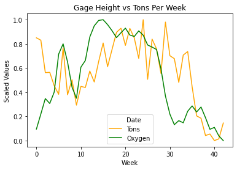

```python
plt.figure(figsize=(16, 8), dpi=150)

# we have passed colors as a list
GH_scaled.plot(label='Gage Height', color=['white', 'orange', 'green'])

# adding title
plt.title('Gage Height vs Tons Per Week')

# adding label to x-axis
plt.xlabel('Week')
plt.ylabel('Scaled Values')

# adding legend.
plt.legend()
```

We can visually see that gage height and tons per week have a correlation.

### Temperature Comparison

The rate of chemical reactions generally increases at higher temperature. Water, particularly groundwater, with higher temperatures can dissolve more minerals from the surrounding rock and will therefore have a higher electrical conductivity. Warm stream water is can affect the aquatic life in the stream. Warm water holds less dissolved oxygen than cool water, and may not contain enough dissolved oxygen for the survival of different species of aquatic life. Some compounds are also more toxic to aquatic life at higher temperatures.

```python
#join mean temperature per day and tons per day into a dataframe so we can graph
TMPTonsPerDayJoin = pd.merge(tonsPerDay, temperature, how='outer', on='Date')
```

```python
# removing Missing Values
TMPTonsPerDayJoin.dropna(inplace=True)

TMPTonsPerDayJoin.head(10)
```

|  | Date | Tons | Temperature Mean |
| --- | --- | --- | --- |
| 988 | 2021-12-11 | 836790.0 | 12.4 |
| 989 | 2021-12-18 | 822326.0 | 12.5 |
| 990 | 2021-12-25 | 624640.0 | 11.1 |
| 991 | 2022-01-01 | 626084.0 | 12.9 |
| 992 | 2022-01-08 | 544656.0 | 10.8 |
| 993 | 2022-01-15 | 491988.0 | 8.1 |
| 994 | 2022-01-22 | 775228.0 | 6.2 |
| 995 | 2022-01-29 | 489344.0 | 5.6 |
| 996 | 2022-02-05 | 581372.0 | 5.6 |
| 997 | 2022-02-12 | 426016.0 | 5.9 |

```python
TMPTonsPerDayJoin.set_index('Date')
```

| Date | Tons | Temperature Mean |
| --- | --- | --- |
| 2021-12-11 | 836790.0 | 12.4 |
| 2021-12-18 | 822326.0 | 12.5 |
| 2021-12-25 | 624640.0 | 11.1 |
| 2022-01-01 | 626084.0 | 12.9 |
| 2022-01-08 | 544656.0 | 10.8 |
| 2022-01-15 | 491988.0 | 8.1 |
| 2022-01-22 | 775228.0 | 6.2 |
| 2022-01-29 | 489344.0 | 5.6 |
| 2022-02-05 | 581372.0 | 5.6 |
| 2022-02-12 | 426016.0 | 5.9 |
| 2022-02-19 | 540250.0 | 6.7 |
| 2022-02-26 | 533744.0 | 7.7 |
| 2022-03-05 | 634100.0 | 7.8 |
| 2022-03-12 | 567522.0 | 9.8 |
| 2022-03-19 | 693000.0 | 11.3 |
| 2022-03-26 | 805372.0 | 12.7 |
| 2022-04-02 | 660750.0 | 14.3 |
| 2022-04-09 | 765900.0 | 14.8 |
| 2022-04-16 | 870418.0 | 15.3 |
| 2022-04-23 | 895067.0 | 16.1 |
| 2022-04-30 | 790572.0 | 17.7 |
| 2022-05-07 | 894250.0 | 20.5 |
| 2022-05-14 | 835730.0 | 20.8 |
| 2022-05-21 | 711200.0 | 22.8 |
| 2022-05-28 | 947300.0 | 23.9 |
| 2022-06-04 | 583551.0 | 24.2 |
| 2022-06-11 | 828930.0 | 25.4 |
| 2022-06-18 | 769450.0 | 27.2 |
| 2022-06-25 | 619210.0 | 29.8 |
| 2022-07-02 | 932872.0 | 29.1 |
| 2022-07-09 | 727500.0 | 29.8 |
| 2022-07-16 | 709790.0 | 31.0 |
| 2022-07-23 | 564672.0 | 30.4 |
| 2022-07-30 | 731275.0 | 30.4 |
| 2022-08-06 | 753326.0 | 29.7 |
| 2022-08-13 | 537618.0 | 29.3 |
| 2022-08-20 | 360585.0 | 29.7 |
| 2022-09-03 | 240500.0 | 29.5 |
| 2022-09-10 | 249727.0 | 28.9 |
| 2022-09-17 | 209600.0 | 27.9 |
| 2022-09-24 | 220300.0 | 28.4 |
| 2022-10-01 | 316850.0 | 25.3 |

```python
TMPTonsPerDayJoin['Date'] = pd.to_numeric(pd.to_datetime(TMPTonsPerDayJoin['Date']))

scaler = MinMaxScaler()

TMP_scaled = scaler.fit_transform(TMPTonsPerDayJoin.to_numpy())
TMP_scaled = pd.DataFrame(TMP_scaled, columns=['Date','Tons', 'Oxygen'])

print("Scaled Dataset Using MinMaxScaler")
TMP_scaled.head()
```

```
Scaled Dataset Using MinMaxScaler
```

|  | Date | Tons | Oxygen |
| --- | --- | --- | --- |
| 0 | 0.000000 | 0.850197 | 0.267717 |
| 1 | 0.023810 | 0.830590 | 0.271654 |
| 2 | 0.047619 | 0.562614 | 0.216535 |
| 3 | 0.071429 | 0.564571 | 0.287402 |
| 4 | 0.095238 | 0.454190 | 0.204724 |

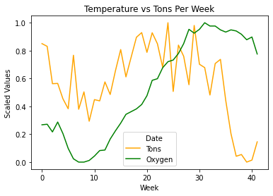

```python
plt.figure(figsize=(16, 8), dpi=150)

# we have passed colors as a list
TMP_scaled.plot(label='Temperature', color=['white', 'orange', 'green'])

# adding title
plt.title('Temperature vs Tons Per Week')

# adding label to x-axis
plt.xlabel('Week')
plt.ylabel('Scaled Values')

# adding legend.
plt.legend()
```

Temperature and tons per week do not have much of a correlation visually.

### Salinity Comparison

Salts can be toxic to freshwater plants and animals and can make water unsafe for drinking, irrigation and livestock watering. Excess salinity can occur in areas where evaporation is high and made worse by repeated use of water for irrigation or water withdrawals, where road de-icers are applied and in mining, oil and gas drilling and wastewater discharges.

```python
#join mean salinity per day and tons per day into a dataframe so we can graph
SalTonsPerDayJoin = pd.merge(tonsPerDay, salinity, how='outer', on='Date')
```

```python
# removing Missing Values
SalTonsPerDayJoin.dropna(inplace=True)

SalTonsPerDayJoin.head(10)
```

|  | Date | Tons | Salinity Mean |
| --- | --- | --- | --- |
| 988 | 2021-12-11 | 836790.0 | 0.2 |
| 989 | 2021-12-18 | 822326.0 | 0.2 |
| 990 | 2021-12-25 | 624640.0 | 0.2 |
| 991 | 2022-01-01 | 626084.0 | 0.2 |
| 992 | 2022-01-08 | 544656.0 | 0.2 |
| 993 | 2022-01-15 | 491988.0 | 0.2 |
| 994 | 2022-01-22 | 775228.0 | 0.1 |
| 995 | 2022-01-29 | 489344.0 | 0.1 |
| 996 | 2022-02-05 | 581372.0 | 0.2 |
| 997 | 2022-02-12 | 426016.0 | 0.2 |

```python
SalTonsPerDayJoin.set_index('Date')
```

| Date | Tons | Salinity Mean |
| --- | --- | --- |
| 2021-12-11 | 836790.0 | 0.2 |
| 2021-12-18 | 822326.0 | 0.2 |
| 2021-12-25 | 624640.0 | 0.2 |
| 2022-01-01 | 626084.0 | 0.2 |
| 2022-01-08 | 544656.0 | 0.2 |
| 2022-01-15 | 491988.0 | 0.2 |
| 2022-01-22 | 775228.0 | 0.1 |
| 2022-01-29 | 489344.0 | 0.1 |
| 2022-02-05 | 581372.0 | 0.2 |
| 2022-02-12 | 426016.0 | 0.2 |
| 2022-02-19 | 540250.0 | 0.2 |
| 2022-02-26 | 533744.0 | 0.2 |
| 2022-03-05 | 634100.0 | 0.1 |
| 2022-03-12 | 567522.0 | 0.1 |
| 2022-03-19 | 693000.0 | 0.1 |
| 2022-03-26 | 805372.0 | 0.1 |
| 2022-04-02 | 660750.0 | 0.1 |
| 2022-04-09 | 765900.0 | 0.2 |
| 2022-04-16 | 870418.0 | 0.2 |
| 2022-04-23 | 895067.0 | 0.2 |
| 2022-04-30 | 790572.0 | 0.2 |
| 2022-05-07 | 894250.0 | 0.2 |
| 2022-05-14 | 835730.0 | 0.2 |
| 2022-05-21 | 711200.0 | 0.2 |
| 2022-05-28 | 947300.0 | 0.2 |
| 2022-06-04 | 583551.0 | 0.2 |
| 2022-06-11 | 828930.0 | 0.2 |
| 2022-06-18 | 769450.0 | 0.2 |
| 2022-06-25 | 619210.0 | 0.2 |
| 2022-07-02 | 932872.0 | 0.2 |
| 2022-07-09 | 727500.0 | 0.2 |
| 2022-07-16 | 709790.0 | 0.2 |
| 2022-07-23 | 564672.0 | 0.2 |
| 2022-07-30 | 731275.0 | 0.2 |
| 2022-08-06 | 753326.0 | 0.2 |
| 2022-08-13 | 537618.0 | 0.2 |
| 2022-08-20 | 360585.0 | 0.2 |
| 2022-09-03 | 240500.0 | 0.2 |
| 2022-09-10 | 249727.0 | 0.2 |
| 2022-09-17 | 209600.0 | 0.2 |
| 2022-09-24 | 220300.0 | 0.2 |
| 2022-10-01 | 316850.0 | 0.2 |

```python
SalTonsPerDayJoin['Date'] = pd.to_numeric(pd.to_datetime(SalTonsPerDayJoin['Date']))

scaler = MinMaxScaler()

Sal_scaled = scaler.fit_transform(SalTonsPerDayJoin.to_numpy())
Sal_scaled = pd.DataFrame(Sal_scaled, columns=['Date','Tons', 'Oxygen'])

print("Scaled Dataset Using MinMaxScaler")
Sal_scaled.head()
```

```
Scaled Dataset Using MinMaxScaler
```

|  | Date | Tons | Oxygen |
| --- | --- | --- | --- |
| 0 | 0.000000 | 0.850197 | 1.0 |
| 1 | 0.023810 | 0.830590 | 1.0 |
| 2 | 0.047619 | 0.562614 | 1.0 |
| 3 | 0.071429 | 0.564571 | 1.0 |
| 4 | 0.095238 | 0.454190 | 1.0 |

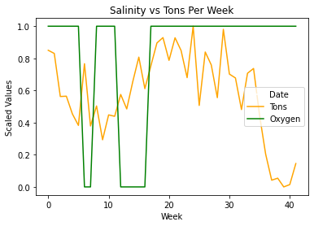

```python
plt.figure(figsize=(16, 8), dpi=150)

# we have passed colors as a list
Sal_scaled.plot(label='Salinity', color=['white', 'orange', 'green'])

# adding title
plt.title('Salinity vs Tons Per Week')

# adding label to x-axis
plt.xlabel('Week')
plt.ylabel('Scaled Values')

# adding legend.
plt.legend()
```

### pH Comparison

The pH of water determines the solubility and the amount that can be utilized by aquatic life of chemical constituents such as nutrients and heavy metals. For example, in addition to affecting how much and what form of phosphorus is most abundant in the water, pH also determines whether aquatic life can use it. In the case of heavy metals, the degree to which they are soluble determines their toxicity. When the pH of water is lower, the metal is more soluble and therefore more toxic.

```python
#join mean pH per day and tons per day into a dataframe so we can graph
pHTonsPerDayJoin = pd.merge(tonsPerDay, pH, how='outer', on='Date')
```

```python
# removing Missing Values
pHTonsPerDayJoin.dropna(inplace=True)

pHTonsPerDayJoin.head(10)
```

|  | Date | Tons | pH Median |
| --- | --- | --- | --- |
| 988 | 2021-12-11 | 836790.0 | 8.0 |
| 989 | 2021-12-18 | 822326.0 | 8.0 |
| 990 | 2021-12-25 | 624640.0 | 8.0 |
| 991 | 2022-01-01 | 626084.0 | 7.9 |
| 992 | 2022-01-08 | 544656.0 | 8.0 |
| 993 | 2022-01-15 | 491988.0 | 7.8 |
| 994 | 2022-01-22 | 775228.0 | 7.8 |
| 995 | 2022-01-29 | 489344.0 | 7.8 |
| 996 | 2022-02-05 | 581372.0 | 7.9 |
| 997 | 2022-02-12 | 426016.0 | 8.0 |

```python
pHTonsPerDayJoin.set_index('Date')
```

| Date | Tons | pH Median |
| --- | --- | --- |
| 2021-12-11 | 836790.0 | 8.0 |
| 2021-12-18 | 822326.0 | 8.0 |
| 2021-12-25 | 624640.0 | 8.0 |
| 2022-01-01 | 626084.0 | 7.9 |
| 2022-01-08 | 544656.0 | 8.0 |
| 2022-01-15 | 491988.0 | 7.8 |
| 2022-01-22 | 775228.0 | 7.8 |
| 2022-01-29 | 489344.0 | 7.8 |
| 2022-02-05 | 581372.0 | 7.9 |
| 2022-02-12 | 426016.0 | 8.0 |
| 2022-02-19 | 540250.0 | 8.0 |
| 2022-02-26 | 533744.0 | 7.9 |
| 2022-03-05 | 634100.0 | 7.7 |
| 2022-03-12 | 567522.0 | 7.6 |
| 2022-03-19 | 693000.0 | 7.6 |
| 2022-03-26 | 805372.0 | 7.7 |
| 2022-04-02 | 660750.0 | 7.7 |
| 2022-04-09 | 765900.0 | 7.7 |
| 2022-04-16 | 870418.0 | 7.7 |
| 2022-04-23 | 895067.0 | 7.7 |
| 2022-04-30 | 790572.0 | 7.6 |
| 2022-05-07 | 894250.0 | 7.7 |
| 2022-05-14 | 835730.0 | 7.8 |
| 2022-05-21 | 711200.0 | 7.7 |
| 2022-05-28 | 947300.0 | 7.8 |
| 2022-06-04 | 583551.0 | 7.8 |
| 2022-06-11 | 828930.0 | 7.8 |
| 2022-06-18 | 769450.0 | 7.8 |
| 2022-06-25 | 619210.0 | 7.8 |
| 2022-07-02 | 932872.0 | 7.9 |
| 2022-07-09 | 727500.0 | 8.0 |
| 2022-07-16 | 709790.0 | 8.1 |
| 2022-07-23 | 564672.0 | 8.1 |
| 2022-07-30 | 731275.0 | 8.0 |
| 2022-08-06 | 753326.0 | 8.0 |
| 2022-08-13 | 537618.0 | 7.9 |
| 2022-08-20 | 360585.0 | 7.9 |
| 2022-09-03 | 240500.0 | 7.9 |
| 2022-09-10 | 249727.0 | 7.9 |
| 2022-09-17 | 209600.0 | 8.0 |
| 2022-09-24 | 220300.0 | 7.9 |
| 2022-10-01 | 316850.0 | 8.0 |

```python
pHTonsPerDayJoin['Date'] = pd.to_numeric(pd.to_datetime(pHTonsPerDayJoin['Date']))

scaler = MinMaxScaler()

pH_scaled = scaler.fit_transform(pHTonsPerDayJoin.to_numpy())
pH_scaled = pd.DataFrame(pH_scaled, columns=['Date','Tons', 'Oxygen'])

print("Scaled Dataset Using MinMaxScaler")
pH_scaled.head()
```

```
Scaled Dataset Using MinMaxScaler
```

|  | Date | Tons | Oxygen |
| --- | --- | --- | --- |
| 0 | 0.000000 | 0.850197 | 0.8 |
| 1 | 0.023810 | 0.830590 | 0.8 |
| 2 | 0.047619 | 0.562614 | 0.8 |
| 3 | 0.071429 | 0.564571 | 0.6 |
| 4 | 0.095238 | 0.454190 | 0.8 |

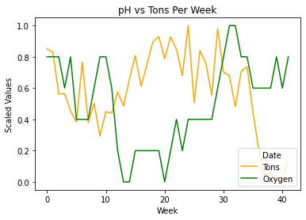

```python
plt.figure(figsize=(16, 8), dpi=150)

# we have passed colors as a list
pH_scaled.plot(label='pH', color=['white', 'orange', 'green'])

# adding title
plt.title('pH vs Tons Per Week')

# adding label to x-axis
plt.xlabel('Week')
plt.ylabel('Scaled Values')

# adding legend.
plt.legend()
```

### Discharge comparison

Discharge is able to detect climatic and environmental change, because the discharge and quality of river water are functions of many climatic, biological, geological, and topographic variables coexisting in the basin.

```python
#join mean discharge per day and tons per day into a dataframe so we can graph
DisTonsPerDayJoin = pd.merge(tonsPerDay, discharge, how='outer', on='Date')
```

```python
# removing Missing Values
DisTonsPerDayJoin.dropna(inplace=True)

DisTonsPerDayJoin.head(10)
```

|  | Date | Tons | Discharge |
| --- | --- | --- | --- |
| 988 | 2021-12-11 | 836790.0 | 248000.0 |
| 989 | 2021-12-18 | 822326.0 | 331000.0 |
| 990 | 2021-12-25 | 624640.0 | 413000.0 |
| 991 | 2022-01-01 | 626084.0 | 387000.0 |
| 992 | 2022-01-08 | 544656.0 | 447000.0 |
| 993 | 2022-01-15 | 491988.0 | 650000.0 |
| 994 | 2022-01-22 | 775228.0 | 725000.0 |
| 995 | 2022-01-29 | 489344.0 | 607000.0 |
| 996 | 2022-02-05 | 581372.0 | 474000.0 |
| 997 | 2022-02-12 | 426016.0 | 415000.0 |

```python
DisTonsPerDayJoin.set_index('Date')
```

| Date | Tons | Discharge |
| --- | --- | --- |
| 2021-12-11 | 836790.0 | 248000.0 |
| 2021-12-18 | 822326.0 | 331000.0 |
| 2021-12-25 | 624640.0 | 413000.0 |
| 2022-01-01 | 626084.0 | 387000.0 |
| 2022-01-08 | 544656.0 | 447000.0 |
| 2022-01-15 | 491988.0 | 650000.0 |
| 2022-01-22 | 775228.0 | 725000.0 |
| 2022-01-29 | 489344.0 | 607000.0 |
| 2022-02-05 | 581372.0 | 474000.0 |
| 2022-02-12 | 426016.0 | 415000.0 |
| 2022-02-19 | 540250.0 | 580000.0 |
| 2022-02-26 | 533744.0 | 615000.0 |
| 2022-03-05 | 634100.0 | 791000.0 |
| 2022-03-12 | 567522.0 | 905000.0 |
| 2022-03-19 | 693000.0 | 963000.0 |
| 2022-03-26 | 805372.0 | 970000.0 |
| 2022-04-02 | 660750.0 | 918000.0 |
| 2022-04-09 | 765900.0 | 855000.0 |
| 2022-04-16 | 870418.0 | 785000.0 |
| 2022-04-23 | 895067.0 | 833000.0 |
| 2022-04-30 | 790572.0 | 881000.0 |
| 2022-05-07 | 894250.0 | 811000.0 |
| 2022-05-14 | 835730.0 | 796000.0 |
| 2022-05-21 | 711200.0 | 853000.0 |
| 2022-05-28 | 947300.0 | 809000.0 |
| 2022-06-04 | 583551.0 | 715000.0 |
| 2022-06-11 | 828930.0 | 697000.0 |
| 2022-06-18 | 769450.0 | 679000.0 |
| 2022-06-25 | 619210.0 | 570000.0 |
| 2022-07-02 | 932872.0 | 427000.0 |
| 2022-07-09 | 727500.0 | 330000.0 |
| 2022-07-16 | 709790.0 | 274000.0 |
| 2022-07-23 | 564672.0 | 295000.0 |
| 2022-07-30 | 731275.0 | 283000.0 |
| 2022-08-06 | 753326.0 | 345000.0 |
| 2022-08-13 | 537618.0 | 374000.0 |
| 2022-08-20 | 360585.0 | 340000.0 |
| 2022-08-27 | 345840.0 | 365000.0 |
| 2022-09-03 | 240500.0 | 306000.0 |
| 2022-09-10 | 249727.0 | 238000.0 |
| 2022-09-17 | 209600.0 | 248000.0 |
| 2022-09-24 | 220300.0 | 193000.0 |
| 2022-10-01 | 316850.0 | 163000.0 |

```python
DisTonsPerDayJoin['Date'] = pd.to_numeric(pd.to_datetime(DisTonsPerDayJoin['Date']))

scaler = MinMaxScaler()

Dis_scaled = scaler.fit_transform(DisTonsPerDayJoin.to_numpy())
Dis_scaled = pd.DataFrame(Dis_scaled, columns=['Date','Tons', 'Oxygen'])

print("Scaled Dataset Using MinMaxScaler")
Dis_scaled.head()
```

```
Scaled Dataset Using MinMaxScaler
```

|  | Date | Tons | Oxygen |
| --- | --- | --- | --- |
| 0 | 0.000000 | 0.850197 | 0.105328 |
| 1 | 0.023810 | 0.830590 | 0.208178 |
| 2 | 0.047619 | 0.562614 | 0.309789 |
| 3 | 0.071429 | 0.564571 | 0.277571 |
| 4 | 0.095238 | 0.454190 | 0.351921 |

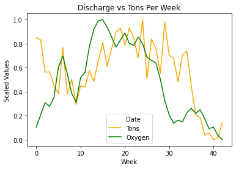

```python
plt.figure(figsize=(16, 8), dpi=150)

# we have passed colors as a list
Dis_scaled.plot(label='Discharge', color=['white', 'orange', 'green'])

# adding title
plt.title('Discharge vs Tons Per Week')

# adding label to x-axis
plt.xlabel('Week')
plt.ylabel('Scaled Values')

# adding legend.
plt.legend()
```

Discharge is correlated with tons Per week.

### Dissolved Oxygen Comparison

Rapidly moving water, such as in a mountain stream or large river, tends to contain a lot of dissolved oxygen, whereas stagnant water contains less. Bacteria in water can consume oxygen as organic matter decays. Excess organic material in lakes and rivers can cause an oxygen-deficient situation that can cause a water body to "die." Aquatic life can have a hard time in stagnant water that has a lot of rotting, organic material in it, especially in summer, when dissolved-oxygen levels are at a seasonal low. Conditions may become especially serious during a period of hot, calm weather, resulting in the loss of many fish. Chemicals can also remove the amount of dissolved oxygen in a body of water as well.

```python
#join mean oxygen per day and tons per day into a dataframe so we can graph
DOTonsPerDayJoin = pd.merge(tonsPerDay, oxygen, how='outer', on='Date')
```

```python
# removing Missing Values
DOTonsPerDayJoin.dropna(inplace=True)

DOTonsPerDayJoin.head(10)
```

|  | Date | Tons | Dissolved Oxygen |
| --- | --- | --- | --- |
| 988 | 2021-12-11 | 836790.0 | 10.2 |
| 989 | 2021-12-18 | 822326.0 | 10.2 |
| 990 | 2021-12-25 | 624640.0 | 10.1 |
| 991 | 2022-01-01 | 626084.0 | 9.8 |
| 992 | 2022-01-08 | 544656.0 | 10.2 |
| 993 | 2022-01-15 | 491988.0 | 10.5 |
| 994 | 2022-01-22 | 775228.0 | 11.3 |
| 995 | 2022-01-29 | 489344.0 | 11.8 |
| 996 | 2022-02-05 | 581372.0 | 12.2 |
| 997 | 2022-02-12 | 426016.0 | 12.2 |

```python
DOTonsPerDayJoin.set_index('Date')
```

| Date | Tons | Dissolved Oxygen |
| --- | --- | --- |
| 2021-12-11 | 836790.0 | 10.2 |
| 2021-12-18 | 822326.0 | 10.2 |
| 2021-12-25 | 624640.0 | 10.1 |
| 2022-01-01 | 626084.0 | 9.8 |
| 2022-01-08 | 544656.0 | 10.2 |
| 2022-01-15 | 491988.0 | 10.5 |
| 2022-01-22 | 775228.0 | 11.3 |
| 2022-01-29 | 489344.0 | 11.8 |
| 2022-02-05 | 581372.0 | 12.2 |
| 2022-02-12 | 426016.0 | 12.2 |
| 2022-02-19 | 540250.0 | 12.1 |
| 2022-02-26 | 533744.0 | 11.3 |
| 2022-03-05 | 634100.0 | 10.7 |
| 2022-03-12 | 567522.0 | 10.0 |
| 2022-03-19 | 693000.0 | 9.6 |
| 2022-03-26 | 805372.0 | 9.2 |
| 2022-04-02 | 660750.0 | 8.8 |
| 2022-04-09 | 765900.0 | 8.4 |
| 2022-04-16 | 870418.0 | 8.4 |
| 2022-04-23 | 895067.0 | 8.1 |
| 2022-04-30 | 790572.0 | 7.7 |
| 2022-05-07 | 894250.0 | 7.1 |
| 2022-05-14 | 835730.0 | 7.3 |
| 2022-05-21 | 711200.0 | 6.7 |
| 2022-05-28 | 947300.0 | 6.5 |
| 2022-06-04 | 583551.0 | 6.8 |
| 2022-06-11 | 828930.0 | 6.6 |
| 2022-06-18 | 769450.0 | 6.2 |
| 2022-06-25 | 619210.0 | 5.6 |
| 2022-07-02 | 932872.0 | 6.1 |
| 2022-07-09 | 727500.0 | 6.4 |
| 2022-07-16 | 709790.0 | 6.4 |
| 2022-07-23 | 564672.0 | 6.4 |
| 2022-07-30 | 731275.0 | 6.3 |
| 2022-08-06 | 753326.0 | 6.3 |
| 2022-08-13 | 537618.0 | 6.2 |
| 2022-08-20 | 360585.0 | 6.0 |
| 2022-08-27 | 345840.0 | 5.6 |
| 2022-09-03 | 240500.0 | 5.9 |
| 2022-09-10 | 249727.0 | 6.1 |
| 2022-09-17 | 209600.0 | 6.7 |
| 2022-09-24 | 220300.0 | 6.5 |
| 2022-10-01 | 316850.0 | 7.2 |

```python
DOTonsPerDayJoin['Date'] = pd.to_numeric(pd.to_datetime(DOTonsPerDayJoin['Date']))

scaler = MinMaxScaler()

DO_scaled = scaler.fit_transform(DOTonsPerDayJoin.to_numpy())
DO_scaled = pd.DataFrame(DO_scaled, columns=['Date','Tons', 'Oxygen'])

print("Scaled Dataset Using MinMaxScaler")
DO_scaled.head()
```

```
Scaled Dataset Using MinMaxScaler
```

|  | Date | Tons | Oxygen |
| --- | --- | --- | --- |
| 0 | 0.000000 | 0.850197 | 0.696970 |
| 1 | 0.023810 | 0.830590 | 0.696970 |
| 2 | 0.047619 | 0.562614 | 0.681818 |
| 3 | 0.071429 | 0.564571 | 0.636364 |
| 4 | 0.095238 | 0.454190 | 0.696970 |

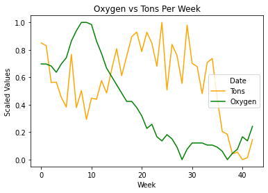

```python
plt.figure(figsize=(16, 8), dpi=150)

# we have passed colors as a list
DO_scaled.plot(label='Oxygen', color=['white', 'orange', 'green'])

# adding title
plt.title('Oxygen vs Tons Per Week')

# adding label to x-axis
plt.xlabel('Week')
plt.ylabel('Scaled Values')

# adding legend.
plt.legend()
```

Oxygen may be negatively correlated with tons per week.

### Nitrate Comparison

Excess nitrogen can cause overstimulation of growth of aquatic plants and algae. Excessive growth of these organisms, in turn, can clog water intakes, use up dissolved oxygen as they decompose, and block light to deeper waters. Lake and reservoir eutrophication can occur, which produces unsightly scums of algae on the water surface, can occasionally result in fish kills, and can even "kill" a lake by depriving it of oxygen. The respiration efficiency of fish and aquatic invertebrates can occur, leading to a decrease in animal and plant diversity, and affects our use of the water.

```python
#join mean nitrate per day and tons per day into a dataframe so we can graph
NitTonsPerDayJoin = pd.merge(tonsPerDay, nitrate, how='outer', on='Date')
```

```python
# removing Missing Values
NitTonsPerDayJoin.dropna(inplace=True)

NitTonsPerDayJoin.head(10)
```

|  | Date | Tons | Nitrate |
| --- | --- | --- | --- |
| 988 | 2021-12-11 | 836790.0 | 1.25 |
| 989 | 2021-12-18 | 822326.0 | 1.15 |
| 990 | 2021-12-25 | 624640.0 | 1.04 |
| 991 | 2022-01-01 | 626084.0 | 1.15 |
| 992 | 2022-01-08 | 544656.0 | 1.19 |
| 993 | 2022-01-15 | 491988.0 | 1.16 |
| 994 | 2022-01-22 | 775228.0 | 1.07 |
| 995 | 2022-01-29 | 489344.0 | 0.97 |
| 996 | 2022-02-05 | 581372.0 | 0.94 |
| 997 | 2022-02-12 | 426016.0 | 1.01 |

```python
NitTonsPerDayJoin.set_index('Date')
```

| Date | Tons | Nitrate |
| --- | --- | --- |
| 2021-12-11 | 836790.0 | 1.25 |
| 2021-12-18 | 822326.0 | 1.15 |
| 2021-12-25 | 624640.0 | 1.04 |
| 2022-01-01 | 626084.0 | 1.15 |
| 2022-01-08 | 544656.0 | 1.19 |
| 2022-01-15 | 491988.0 | 1.16 |
| 2022-01-22 | 775228.0 | 1.07 |
| 2022-01-29 | 489344.0 | 0.97 |
| 2022-02-05 | 581372.0 | 0.94 |
| 2022-02-12 | 426016.0 | 1.01 |
| 2022-02-19 | 540250.0 | 1.03 |
| 2022-02-26 | 533744.0 | 1.19 |
| 2022-03-05 | 634100.0 | 1.01 |
| 2022-03-12 | 567522.0 | 1.04 |
| 2022-03-19 | 693000.0 | 1.08 |
| 2022-03-26 | 805372.0 | 0.98 |
| 2022-04-02 | 660750.0 | 0.89 |
| 2022-04-09 | 765900.0 | 1.14 |
| 2022-04-16 | 870418.0 | 1.40 |
| 2022-04-23 | 895067.0 | 1.27 |
| 2022-04-30 | 790572.0 | 1.03 |
| 2022-05-07 | 894250.0 | 1.06 |
| 2022-05-14 | 835730.0 | 1.32 |
| 2022-05-21 | 711200.0 | 1.39 |
| 2022-05-28 | 947300.0 | 1.38 |
| 2022-06-04 | 583551.0 | 1.44 |
| 2022-06-11 | 828930.0 | 1.39 |
| 2022-06-18 | 769450.0 | 1.72 |
| 2022-06-25 | 619210.0 | 1.51 |
| 2022-07-02 | 932872.0 | 1.82 |
| 2022-07-09 | 727500.0 | 1.93 |
| 2022-07-16 | 709790.0 | 1.83 |
| 2022-07-23 | 564672.0 | 1.70 |
| 2022-07-30 | 731275.0 | 1.52 |
| 2022-08-06 | 753326.0 | 1.37 |
| 2022-08-13 | 537618.0 | 1.21 |
| 2022-08-20 | 360585.0 | 0.81 |
| 2022-08-27 | 345840.0 | 0.55 |
| 2022-09-03 | 240500.0 | 0.44 |
| 2022-09-10 | 249727.0 | 0.55 |
| 2022-09-17 | 209600.0 | 0.51 |

```python
NitTonsPerDayJoin['Date'] = pd.to_numeric(pd.to_datetime(NitTonsPerDayJoin['Date']))

scaler = MinMaxScaler()

N_scaled = scaler.fit_transform(NitTonsPerDayJoin.to_numpy())
N_scaled = pd.DataFrame(N_scaled, columns=['Date','Tons', 'Nitrate'])

print("Scaled Dataset Using MinMaxScaler")
PM_scaled.head()
```

```
Scaled Dataset Using MinMaxScaler
```

|  | Tons | ParticulateMatter |
| --- | --- | --- |
| 0 | 0.512689 | 0.515600 |
| 1 | 0.262174 | 1.000000 |
| 2 | 0.460287 | 0.650910 |
| 3 | 0.367083 | 0.411848 |
| 4 | 0.476663 | 0.130182 |

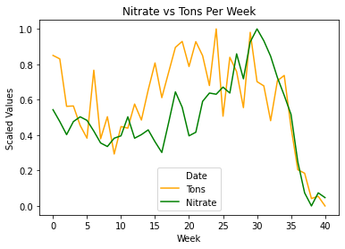

```python
plt.figure(figsize=(16, 8), dpi=150)

# we have passed colors as a list
N_scaled.plot(label='Nitrate', color=['white', 'orange', 'green'])

# adding title
plt.title('Nitrate vs Tons Per Week')

# adding label to x-axis
plt.xlabel('Week')
plt.ylabel('Scaled Values')

# adding legend.
plt.legend()
```

Nitrate looks very correlated with tons moved per week.

Nitrate, discharge, and gage height in the water are correlated with barge movements, but we cannot prove that barge movements cause the increases in nitrates, discharge, and gage heights without further analysis.

# Models

We are going to build a linear regression that will take in barge movements and predict the air quality, specifically the amount of methane in the air. This will help us answer one of our primary questions: Do barge movements in the Mississippi affect the air quality in New Orleans?

```python
import numpy as np
import matplotlib.pyplot as plt  # To visualize
import pandas as pd  # To read data
from sklearn.linear_model import LinearRegression
```

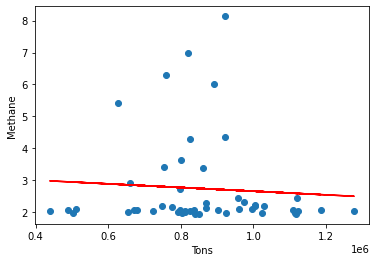

```python
X = methaneTonsPerDayJoin.iloc[:, 0].values.reshape(-1, 1)
Y = methaneTonsPerDayJoin.iloc[:, 1].values.reshape(-1, 1)
linear_regressor = LinearRegression()
linear_regressor.fit(X, Y)
Y_pred = linear_regressor.predict(X)

plt.scatter(X, Y)
plt.plot(X, Y_pred, color='red')
plt.xlabel('Tons')
plt.ylabel('Methane')
plt.show()
```

### What we have learned:

Although these factors may not completely show what impact the barges are making, they are still continuing to impact the environment around New Orleans and Louisiana as a whole. We would have loved to have found a dataset on wildlife impacts to analyze against all of these factors.

# References

https://www.epa.gov/gmi/importance-methane#:~:text=Methane%20(CH4)%20is%20a,%2Dinfluenced)%20and%20natural%20sources.

https://www.epa.gov/so2-pollution/sulfur-dioxide-basics

https://www.indoorairhygiene.org/pm2-5-explained/#:~:text=Most%20studies%20indicate%20PM2.,breathing%20issues%20such%20as%20asthma.

https://www.noaa.gov/news-release/increase-in-atmospheric-methane-set-another-record-during-2021#:~:text=Methane%20in%20the%20atmosphere%20is,ruminant%20animals%20such%20as%20cows.

https://www.unep.org/news-and-stories/story/methane-emissions-are-driving-climate-change-heres-how-reduce-them

https://waterdata.usgs.gov/nwis/inventory/?site_no=07374000

https://www.usgs.gov/special-topics/water-science-school/science/turbidity-and-water#:~:text=Turbidity%20is%20the%20measure%20of,light%2C%20the%20higher%20the%20turbidity.

https://waterdata.usgs.gov/blog/gage_height/#:~:text=Gage%20height%20is%20the%20distance,accommodate%20for%20stream%20channel%20changes.

https://www.usgs.gov/special-topics/water-science-school/science/temperature-and-water#:~:text=Temperature%20is%20also%20important%20because,have%20a%20higher%20electrical%20conductivity.

https://www.epa.gov/national-aquatic-resource-surveys/indicators-salinity#:~:text=It%20is%20a%20strong%20contributor,as%20density%20and%20heat%20capacity.

https://www.usgs.gov/special-topics/water-science-school/science/dissolved-oxygen-and-water

https://www.usgs.gov/special-topics/water-science-school/science/nitrogen-and-water

https://www.usgs.gov/special-topics/water-science-school/science/ph-and-water#:~:text=oil%20or%20alcohol.-,pH%20is%20a%20measure%20of%20how%20acidic%2Fbasic%20water%20is,hydroxyl%20ions%20in%20the%20water.

```python
%%shell
jupyter nbconvert --to html FinalProject.ipynb
```

[output not shown]

[output cut: 107 more lines]

[output not shown]

[output not shown]